# modling_forDSM

gaohong

2019年6月30日

# 设置工作路径，加载包

```r
library(rgdal)
library(raster)
library(randomForest)
```

# 构建环境因子图层

```r
setwd("E:/otherWork/02_1/soil2019-rewrite/EnFactor")

files<-c("DEM.tif","Slope.tif","PlanC.tif","ProfileC.tif","TWI.tif","Bedrock.tif","LSF.tif","VD.tif","RSP.tif")

covStack <- raster(files[1])
for (i in 2:length(files)) {
  covStack <- stack(covStack, files[i])
}

#设置读取样点数据路径
point_shp_folder="E:/otherWork/02_1/soil2019-rewrite/allTrainingSamples_shp/"

#设置最终结果tif的保存路径
result_tif_folder="E:/otherWork/02_1/soil2019-rewrite/result_mapTif/"

##设置随机数种子
set.seed(2019)

soil_type<-c(1,3,7,20,21,23,30,31,501,502,503)  # 41样本数量太少，删掉。
sampleNum_dict<-list()
```

# DEM

SNA DEM ns3 15

```r
mn="All_pSNA_DEM_NS3_pen15"

shpPoint<-readOGR(paste(point_shp_folder,mn,".shp",sep = "")) ###
sampData <- extract(covStack, shpPoint, sp = TRUE,method = "simple")

sampData<-sampData@data

sampData<-sampData[sampData$soilID %in% soil_type,]

sampData<-na.omit(sampData)

print(dim(sampData))
```

```
## [1] 1040   10
```

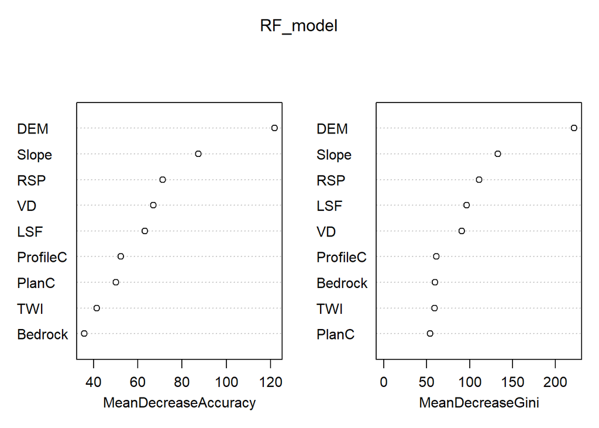

```r
sampleNum_dict[mn]<-nrow(sampData)

sampData$Bedrock<- droplevels(as.factor(sampData$Bedrock))
sampData$soilID<- droplevels(as.factor(sampData$soilID))

RF_model<-randomForest(soilID ~.,data = sampData,
                       importance = TRUE, proximity = FALSE,
                       ntree=1000,type="classification")

varImpPlot(RF_model)
```

```r
print(RF_model)
```

```
##
## Call:
##  randomForest(formula = soilID ~ ., data = sampData, importance = TRUE,      proximity = FALSE, ntree = 1000, type = "classification")
##                Type of random forest: classification
##                      Number of trees: 1000
## No. of variables tried at each split: 3
##
##         OOB estimate of  error rate: 16.73%
## Confusion matrix:
##     1  20 21 23  3 30 31 501 502 503   7 class.error
## 1   3   0  0  0  1  0  0   0   0   0   0  0.25000000
## 20  0 124 10  0  0  0  0   0   0  17   9  0.22500000
## 21  0  21 36  0  0  0  0   0   0   3   0  0.40000000
## 23  0   0  0 80  0  6  1   0   0  12   3  0.21568627
## 3   0   0  0  0 50  0  0   5   0   0   0  0.09090909
## 30  0   0  0 16  0 15  2   0   0   0   0  0.54545455
## 31  0   0  0  2  0  1 37   0   0   0   0  0.07500000
## 501 0   0  0  0  7  0  0 165   0   0   0  0.04069767
## 502 0   2  2  0  0  0  0   7  10   0   1  0.54545455
## 503 0  12  0  4  0  0  0   0   0 223   7  0.09349593
## 7   0  10  0  0  0  0  0   0   2  11 123  0.15753425
```

```r
map_RF <- predict(covStack, RF_model, paste(result_tif_folder,mn,".tif",sep=""),
                  format = "GTiff", datatype = "FLT4S", overwrite = TRUE)

rm("mn","shpPoint","sampData","RF_model","map_RF")
```

RAN DEM ns3 15

```r
mn="All_pRAN_DEM_NS3_pen15"

shpPoint<-readOGR(paste(point_shp_folder,mn,".shp",sep = "")) ###
sampData <- extract(covStack, shpPoint, sp = TRUE,method = "simple")

sampData<-sampData@data

sampData<-sampData[sampData$soilID %in% soil_type,]

sampData<-na.omit(sampData)

print(dim(sampData))
```

```
## [1] 1042   10
```

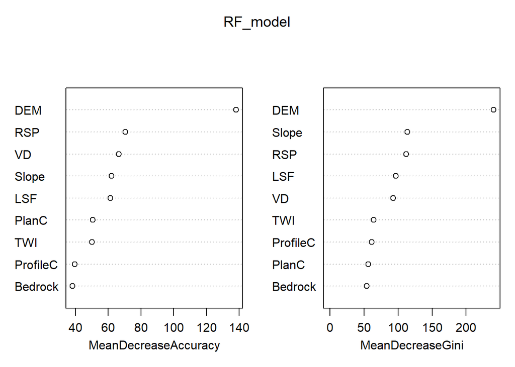

```r
sampleNum_dict[mn]<-nrow(sampData)

sampData$Bedrock<- droplevels(as.factor(sampData$Bedrock))
sampData$soilID<- droplevels(as.factor(sampData$soilID))

RF_model<-randomForest(soilID ~.,data = sampData,
                       importance = TRUE, proximity = FALSE,
                       ntree=1000,type="classification")

varImpPlot(RF_model)
```

```r
print(RF_model)
```

```
##
## Call:
##  randomForest(formula = soilID ~ ., data = sampData, importance = TRUE,      proximity = FALSE, ntree = 1000, type = "classification")
##                Type of random forest: classification
##                      Number of trees: 1000
## No. of variables tried at each split: 3
##
##         OOB estimate of  error rate: 24.28%
## Confusion matrix:
##     1 20 21 23  3 30 31 501 502 503   7 class.error
## 1   4  0  0  0  2  0  0   0   0   0   0   0.3333333
## 20  0 96 19  0  0  0  0   3   0  25  17   0.4000000
## 21  0 19 37  0  0  0  0   0   1   2   1   0.3833333
## 23  0  0  0 75  0  5  4   0   0  17   1   0.2647059
## 3   0  0  0  0 48  0  0   7   0   0   0   0.1272727
## 30  0  0  0  6  0 20  4   0   0   0   3   0.3939394
## 31  0  0  0  9  0  3 26   0   0   2   0   0.3500000
## 501 0  1  0  0  8  0  0 157   0   0   6   0.0872093
## 502 0  6  1  0  0  0  0   3  10   1   1   0.5454545
## 503 0 21  1 12  0  0  0   1   0 203   8   0.1747967
## 7   0 14  0  4  0  2  0   5   1   7 113   0.2260274
```

```r
map_RF <- predict(covStack, RF_model, paste(result_tif_folder,mn,".tif",sep=""),
                  format = "GTiff", datatype = "FLT4S", overwrite = TRUE)

rm("mn","shpPoint","sampData","RF_model","map_RF")
```

SNA DEM ns3 30

```r
mn="All_pSNA_DEM_NS3_pen30"

shpPoint<-readOGR(paste(point_shp_folder,mn,".shp",sep = "")) ###
sampData <- extract(covStack, shpPoint, sp = TRUE,method = "simple")

sampData<-sampData@data

sampData<-sampData[sampData$soilID %in% soil_type,]

sampData<-na.omit(sampData)

print(dim(sampData))
```

```
## [1] 2040   10
```

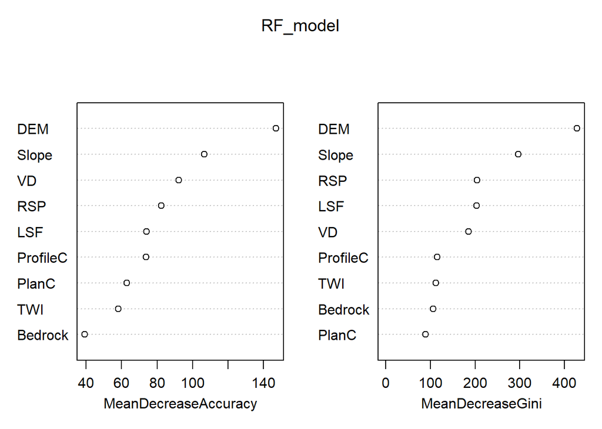

```r
sampleNum_dict[mn]<-nrow(sampData)

sampData$Bedrock<- droplevels(as.factor(sampData$Bedrock))
sampData$soilID<- droplevels(as.factor(sampData$soilID))

RF_model<-randomForest(soilID ~.,data = sampData,
                       importance = TRUE, proximity = FALSE,
                       ntree=1000,type="classification")

varImpPlot(RF_model)
```

```r
print(RF_model)
```

```
##
## Call:
##  randomForest(formula = soilID ~ ., data = sampData, importance = TRUE,      proximity = FALSE, ntree = 1000, type = "classification")
##                Type of random forest: classification
##                      Number of trees: 1000
## No. of variables tried at each split: 3
##
##         OOB estimate of  error rate: 15.49%
## Confusion matrix:
##     1  20 21  23  3 30 31 501 502 503   7 class.error
## 1   8   0  0   0  2  0  0   0   0   0   0  0.20000000
## 20  0 239 18   0  0  0  0   1   1  29  25  0.23642173
## 21  0  31 77   0  0  0  0   0   1   4   0  0.31858407
## 23  0   0  0 156  0 16  3   0   0  16   3  0.19587629
## 3   1   0  0   0 98  0  0  11   0   0   0  0.10909091
## 30  0   0  0  18  0 43  2   0   0   0   0  0.31746032
## 31  0   0  0   5  0  1 73   0   0   0   0  0.07594937
## 501 0   0  0   0 12  0  0 330   0   0   0  0.03508772
## 502 0   4  2   0  0  0  0   8  23   1   3  0.43902439
## 503 0  25  0  13  0  0  0   0   0 431  19  0.11680328
## 7   0  15  0   1  0  1  0   1   2  21 246  0.14285714
```

```r
map_RF <- predict(covStack, RF_model, paste(result_tif_folder,mn,".tif",sep=""),
                  format = "GTiff", datatype = "FLT4S", overwrite = TRUE)

rm("mn","shpPoint","sampData","RF_model","map_RF")
```

RAN DEM ns3 30

```r
mn="All_pRAN_DEM_NS3_pen30"

shpPoint<-readOGR(paste(point_shp_folder,mn,".shp",sep = "")) ###
sampData <- extract(covStack, shpPoint, sp = TRUE,method = "simple")

sampData<-sampData@data

sampData<-sampData[sampData$soilID %in% soil_type,]

sampData<-na.omit(sampData)

print(dim(sampData))
```

```
## [1] 2042   10
```

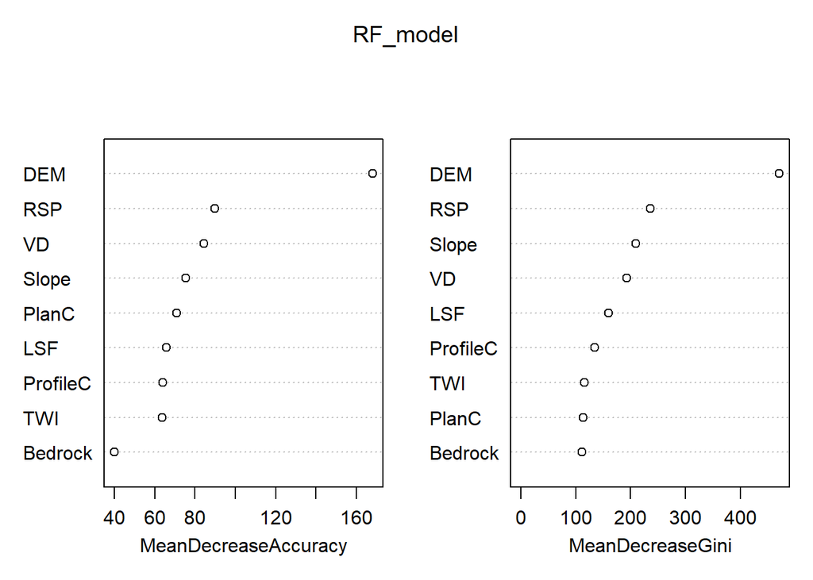

```r
sampleNum_dict[mn]<-nrow(sampData)

sampData$Bedrock<- droplevels(as.factor(sampData$Bedrock))
sampData$soilID<- droplevels(as.factor(sampData$soilID))

RF_model<-randomForest(soilID ~.,data = sampData,
                       importance = TRUE, proximity = FALSE,
                       ntree=1000,type="classification")

varImpPlot(RF_model)
```

```r
print(RF_model)
```

```
##
## Call:
##  randomForest(formula = soilID ~ ., data = sampData, importance = TRUE,      proximity = FALSE, ntree = 1000, type = "classification")
##                Type of random forest: classification
##                      Number of trees: 1000
## No. of variables tried at each split: 3
##
##         OOB estimate of  error rate: 21.35%
## Confusion matrix:
##      1  20 21  23  3 30 31 501 502 503   7 class.error
## 1   12   0  0   0  0  0  0   0   0   0   0   0.0000000
## 20   0 208 21   0  0  0  0   5   1  51  27   0.3354633
## 21   0  35 69   0  0  0  0   1   1   7   0   0.3893805
## 23   0   0  0 141  0  7  9   0   0  31   6   0.2731959
## 3    0   0  0   0 85  0  0  25   0   0   0   0.2272727
## 30   0   0  0  13  0 41  6   0   0   0   3   0.3492063
## 31   0   0  0  12  0  2 65   0   0   0   0   0.1772152
## 501  0   4  0   0 22  0  0 306   0   0  10   0.1052632
## 502  0   4  2   0  0  0  0   1  29   1   4   0.2926829
## 503  0  27  6  23  0  0  0   0   2 418  12   0.1434426
## 7    0  22  0   2  0  2  0  12   2  15 232   0.1916376
```

```r
map_RF <- predict(covStack, RF_model, paste(result_tif_folder,mn,".tif",sep=""),
                  format = "GTiff", datatype = "FLT4S", overwrite = TRUE)

rm("mn","shpPoint","sampData","RF_model","map_RF")
```

SNA DEM ns3 45

```r
mn="All_pSNA_DEM_NS3_pen45"

shpPoint<-readOGR(paste(point_shp_folder,mn,".shp",sep = "")) ###
sampData <- extract(covStack, shpPoint, sp = TRUE,method = "simple")

sampData<-sampData@data

sampData<-sampData[sampData$soilID %in% soil_type,]

sampData<-na.omit(sampData)

print(dim(sampData))
```

```
## [1] 3036   10
```

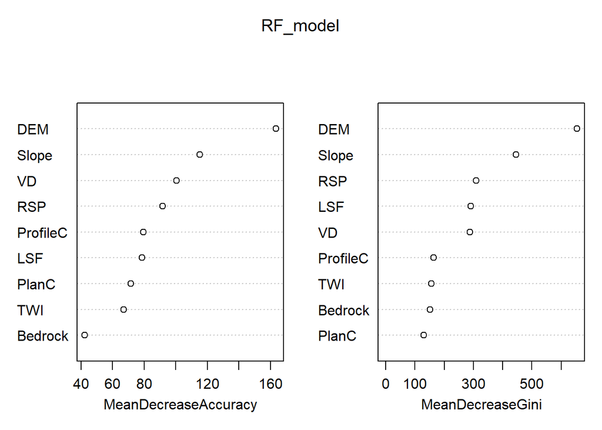

```r
sampleNum_dict[mn]<-nrow(sampData)

sampData$Bedrock<- droplevels(as.factor(sampData$Bedrock))
sampData$soilID<- droplevels(as.factor(sampData$soilID))

RF_model<-randomForest(soilID ~.,data = sampData,
                       importance = TRUE, proximity = FALSE,
                       ntree=1000,type="classification")

varImpPlot(RF_model)
```

```r
print(RF_model)
```

```
##
## Call:
##  randomForest(formula = soilID ~ ., data = sampData, importance = TRUE,      proximity = FALSE, ntree = 1000, type = "classification")
##                Type of random forest: classification
##                      Number of trees: 1000
## No. of variables tried at each split: 3
##
##         OOB estimate of  error rate: 14.16%
## Confusion matrix:
##      1  20  21  23   3 30  31 501 502 503   7 class.error
## 1   14   0   0   0   2  0   0   0   0   0   0  0.12500000
## 20   0 368  30   0   0  0   0   0   1  31  34  0.20689655
## 21   0  54 105   0   0  0   0   0   1   7   0  0.37125749
## 23   0   0   0 240   0 18   7   0   0  18   4  0.16376307
## 3    2   0   0   0 141  0   0  21   0   0   0  0.14024390
## 30   0   0   0  16   0 72   3   0   0   0   1  0.21739130
## 31   0   0   0   7   0  4 107   0   0   0   0  0.09322034
## 501  0   0   0   0  19  0   0 492   0   0   2  0.04093567
## 502  0   2   1   0   0  0   0   5  48   1   4  0.21311475
## 503  0  40   1  16   0  0   0   0   0 651  19  0.10453920
## 7    0  24   0   3   0  1   0   3   3  25 368  0.13817330
```

```r
map_RF <- predict(covStack, RF_model, paste(result_tif_folder,mn,".tif",sep=""),
                  format = "GTiff", datatype = "FLT4S", overwrite = TRUE)

rm("mn","shpPoint","sampData","RF_model","map_RF")
```

RAN DEM ns3 45

```r
mn="All_pRAN_DEM_NS3_pen45"

shpPoint<-readOGR(paste(point_shp_folder,mn,".shp",sep = "")) ###
sampData <- extract(covStack, shpPoint, sp = TRUE,method = "simple")

sampData<-sampData@data

sampData<-sampData[sampData$soilID %in% soil_type,]

sampData<-na.omit(sampData)

print(dim(sampData))
```

```
## [1] 3038   10
```

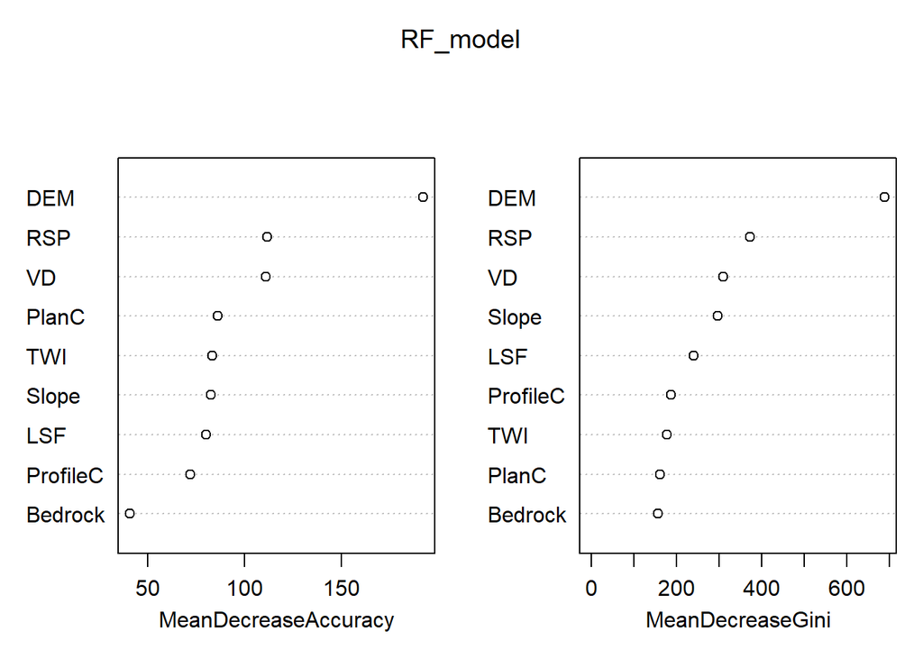

```r
sampleNum_dict[mn]<-nrow(sampData)

sampData$Bedrock<- droplevels(as.factor(sampData$Bedrock))
sampData$soilID<- droplevels(as.factor(sampData$soilID))

RF_model<-randomForest(soilID ~.,data = sampData,
                       importance = TRUE, proximity = FALSE,
                       ntree=1000,type="classification")

varImpPlot(RF_model)
```

```r
print(RF_model)
```

```
##
## Call:
##  randomForest(formula = soilID ~ ., data = sampData, importance = TRUE,      proximity = FALSE, ntree = 1000, type = "classification")
##                Type of random forest: classification
##                      Number of trees: 1000
## No. of variables tried at each split: 3
##
##         OOB estimate of  error rate: 17.74%
## Confusion matrix:
##      1  20 21  23   3 30 31 501 502 503   7 class.error
## 1   15   0  0   0   3  0  0   0   0   0   0  0.16666667
## 20   0 335 31   0   0  0  0   4   0  68  26  0.27801724
## 21   0  54 99   0   0  0  0   1   1  11   1  0.40718563
## 23   0   0  0 226   0 16  6   0   0  31   8  0.21254355
## 3    1   0  0   0 124  0  0  39   0   0   0  0.24390244
## 30   0   0  0  10   0 73  4   0   0   1   4  0.20652174
## 31   0   0  0  13   0  6 98   0   0   1   0  0.16949153
## 501  0   5  0   0  22  0  0 478   0   0   8  0.06822612
## 502  0   3  1   0   0  0  0   2  52   0   3  0.14754098
## 503  0  39  2  24   0  2  0   0   1 643  16  0.11554333
## 7    0  28  0   3   0  4  0  17   2  17 356  0.16627635
```

```r
map_RF <- predict(covStack, RF_model, paste(result_tif_folder,mn,".tif",sep=""),
                  format = "GTiff", datatype = "FLT4S", overwrite = TRUE)

rm("mn","shpPoint","sampData","RF_model","map_RF")
```

SNA DEM ns3 60

```r
mn="All_pSNA_DEM_NS3_pen60"

shpPoint<-readOGR(paste(point_shp_folder,mn,".shp",sep = "")) ###
sampData <- extract(covStack, shpPoint, sp = TRUE,method = "simple")

sampData<-sampData@data

sampData<-sampData[sampData$soilID %in% soil_type,]

sampData<-na.omit(sampData)

print(dim(sampData))
```

```
## [1] 4040   10
```

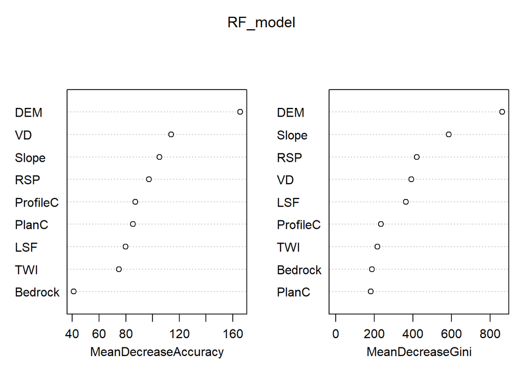

```r
sampleNum_dict[mn]<-nrow(sampData)

sampData$Bedrock<- droplevels(as.factor(sampData$Bedrock))
sampData$soilID<- droplevels(as.factor(sampData$soilID))

RF_model<-randomForest(soilID ~.,data = sampData,
                       importance = TRUE, proximity = FALSE,
                       ntree=1000,type="classification")

varImpPlot(RF_model)
```

```r
print(RF_model)
```

```
##
## Call:
##  randomForest(formula = soilID ~ ., data = sampData, importance = TRUE,      proximity = FALSE, ntree = 1000, type = "classification")
##                Type of random forest: classification
##                      Number of trees: 1000
## No. of variables tried at each split: 3
##
##         OOB estimate of  error rate: 15.25%
## Confusion matrix:
##      1  20  21  23   3 30  31 501 502 503   7 class.error
## 1   19   0   0   0   3  0   0   0   0   0   0  0.13636364
## 20   0 470  42   0   0  0   0   0   2  60  42  0.23701299
## 21   0  81 134   0   0  0   0   0   1   5   0  0.39366516
## 23   0   0   0 319   0 21   9   0   0  23   8  0.16052632
## 3    4   0   0   0 190  0   0  25   0   0   0  0.13242009
## 30   0   0   0  16   0 99   5   0   0   0   3  0.19512195
## 31   0   0   0  11   0  3 143   0   0   0   0  0.08917197
## 501  0   0   0   0  30  0   0 648   1   0   4  0.05124451
## 502  0   1   1   0   0  0   0   2  70   2   5  0.13580247
## 503  0  63   1  25   0  1   0   0   1 850  29  0.12371134
## 7    0  35   0   5   0  2   0   6   6  32 482  0.15140845
```

```r
map_RF <- predict(covStack, RF_model, paste(result_tif_folder,mn,".tif",sep=""),
                  format = "GTiff", datatype = "FLT4S", overwrite = TRUE)

rm("mn","shpPoint","sampData","RF_model","map_RF")
```

RAN DEM ns3 60

```r
mn="All_pRAN_DEM_NS3_pen60"

shpPoint<-readOGR(paste(point_shp_folder,mn,".shp",sep = "")) ###
sampData <- extract(covStack, shpPoint, sp = TRUE,method = "simple")

sampData<-sampData@data

sampData<-sampData[sampData$soilID %in% soil_type,]

sampData<-na.omit(sampData)

print(dim(sampData))
```

```
## [1] 4041   10
```

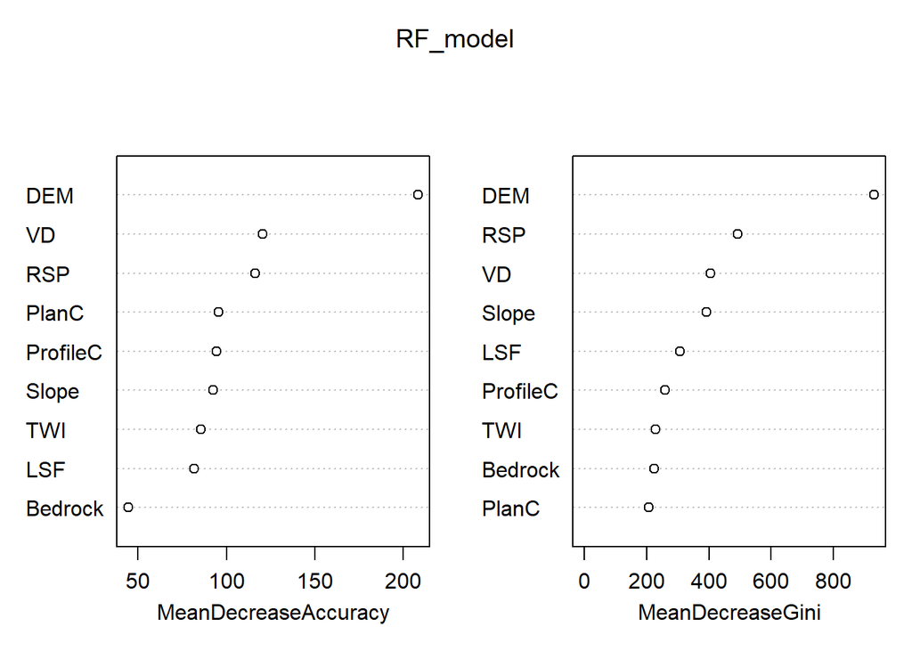

```r
sampleNum_dict[mn]<-nrow(sampData)

sampData$Bedrock<- droplevels(as.factor(sampData$Bedrock))
sampData$soilID<- droplevels(as.factor(sampData$soilID))

RF_model<-randomForest(soilID ~.,data = sampData,
                       importance = TRUE, proximity = FALSE,
                       ntree=1000,type="classification")

varImpPlot(RF_model)
```

```r
print(RF_model)
```

```
##
## Call:
##  randomForest(formula = soilID ~ ., data = sampData, importance = TRUE,      proximity = FALSE, ntree = 1000, type = "classification")
##                Type of random forest: classification
##                      Number of trees: 1000
## No. of variables tried at each split: 3
##
##         OOB estimate of  error rate: 17.57%
## Confusion matrix:
##      1  20  21  23   3 30  31 501 502 503   7 class.error
## 1   18   0   0   0   5  0   0   0   0   0   0   0.2173913
## 20   0 453  32   0   0  0   0   3   3  85  40   0.2646104
## 21   0  80 129   0   0  0   0   2   1   8   1   0.4162896
## 23   0   0   0 295   0 19   6   0   0  47  13   0.2236842
## 3    3   0   0   0 171  0   0  45   0   0   0   0.2191781
## 30   0   0   0  19   0 96   6   0   0   1   1   0.2195122
## 31   0   0   0  17   0  7 132   0   0   1   0   0.1592357
## 501  0   6   0   0  36  0   0 631   1   0   9   0.0761347
## 502  0   4   1   0   0  0   0   1  68   1   6   0.1604938
## 503  0  48   7  21   0  3   0   0   2 863  26   0.1103093
## 7    0  38   1   5   0  3   0  19   4  23 475   0.1637324
```

```r
map_RF <- predict(covStack, RF_model, paste(result_tif_folder,mn,".tif",sep=""),
                  format = "GTiff", datatype = "FLT4S", overwrite = TRUE)

rm("mn","shpPoint","sampData","RF_model","map_RF")
```

SNA DEM ns3 75

```r
mn="All_pSNA_DEM_NS3_pen75"

shpPoint<-readOGR(paste(point_shp_folder,mn,".shp",sep = "")) ###
sampData <- extract(covStack, shpPoint, sp = TRUE,method = "simple")

sampData<-sampData@data

sampData<-sampData[sampData$soilID %in% soil_type,]

sampData<-na.omit(sampData)

print(dim(sampData))
```

```
## [1] 5036   10
```

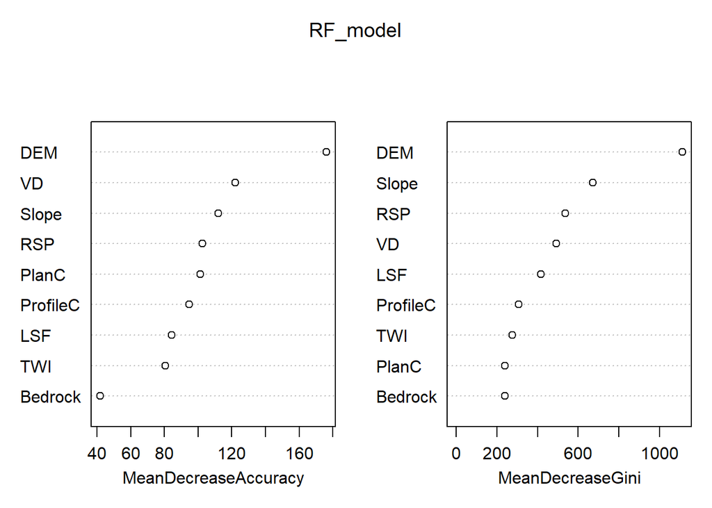

```r
sampleNum_dict[mn]<-nrow(sampData)

sampData$Bedrock<- droplevels(as.factor(sampData$Bedrock))
sampData$soilID<- droplevels(as.factor(sampData$soilID))

RF_model<-randomForest(soilID ~.,data = sampData,
                       importance = TRUE, proximity = FALSE,
                       ntree=1000,type="classification")

varImpPlot(RF_model)
```

```r
print(RF_model)
```

```
##
## Call:
##  randomForest(formula = soilID ~ ., data = sampData, importance = TRUE,      proximity = FALSE, ntree = 1000, type = "classification")
##                Type of random forest: classification
##                      Number of trees: 1000
## No. of variables tried at each split: 3
##
##         OOB estimate of  error rate: 15.89%
## Confusion matrix:
##      1  20  21  23   3  30  31 501 502  503   7 class.error
## 1   24   0   0   0   4   0   0   0   0    0   0  0.14285714
## 20   0 587  46   0   0   0   0   2   1   80  50  0.23368146
## 21   0  95 164   0   0   0   0   0   0   12   3  0.40145985
## 23   0   0   0 389   0  25   8   0   0   34  19  0.18105263
## 3    3   0   0   0 235   0   0  34   0    0   0  0.13602941
## 30   0   0   0  21   0 121   7   0   0    0   4  0.20915033
## 31   0   0   0  12   0   5 179   0   0    0   0  0.08673469
## 501  0   1   0   0  39   0   0 803   1    0  10  0.05971897
## 502  0   1   1   0   0   0   0   2  89    3   5  0.11881188
## 503  0  84   2  39   0   1   0   0   2 1046  34  0.13410596
## 7    0  46   0   9   0   2   0   7   7   39 599  0.15514810
```

```r
map_RF <- predict(covStack, RF_model, paste(result_tif_folder,mn,".tif",sep=""),
                  format = "GTiff", datatype = "FLT4S", overwrite = TRUE)

rm("mn","shpPoint","sampData","RF_model","map_RF")
```

RAN DEM ns3 75

```r
mn="All_pRAN_DEM_NS3_pen75"

shpPoint<-readOGR(paste(point_shp_folder,mn,".shp",sep = "")) ###
sampData <- extract(covStack, shpPoint, sp = TRUE,method = "simple")

sampData<-sampData@data

sampData<-sampData[sampData$soilID %in% soil_type,]

sampData<-na.omit(sampData)

print(dim(sampData))
```

```
## [1] 5037   10
```

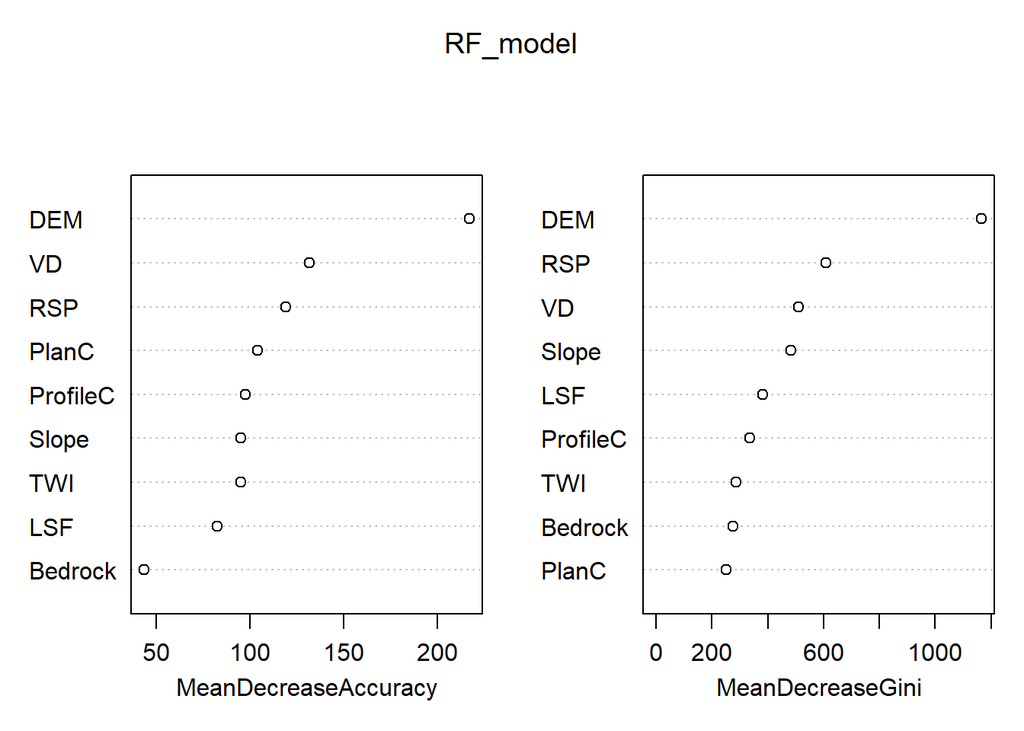

```r
sampleNum_dict[mn]<-nrow(sampData)

sampData$Bedrock<- droplevels(as.factor(sampData$Bedrock))
sampData$soilID<- droplevels(as.factor(sampData$soilID))

RF_model<-randomForest(soilID ~.,data = sampData,
                       importance = TRUE, proximity = FALSE,
                       ntree=1000,type="classification")

varImpPlot(RF_model)
```

```r
print(RF_model)
```

```
##
## Call:
##  randomForest(formula = soilID ~ ., data = sampData, importance = TRUE,      proximity = FALSE, ntree = 1000, type = "classification")
##                Type of random forest: classification
##                      Number of trees: 1000
## No. of variables tried at each split: 3
##
##         OOB estimate of  error rate: 15.54%
## Confusion matrix:
##      1  20  21  23   3  30  31 501 502  503   7 class.error
## 1   24   0   0   0   5   0   0   0   0    0   0  0.17241379
## 20   0 596  33   1   0   0   0   4   4   88  40  0.22193211
## 21   0  97 161   0   0   0   0   1   0   13   2  0.41240876
## 23   0   1   0 383   0  19  10   0   0   49  13  0.19368421
## 3    2   0   0   0 217   0   0  53   0    0   0  0.20220588
## 30   0   0   0  17   0 130   3   0   0    0   3  0.15032680
## 31   0   0   0  20   0   4 172   0   0    0   0  0.12244898
## 501  0   4   0   0  38   0   0 793   1    0  18  0.07142857
## 502  0   2   1   0   0   0   0   1  88    1   8  0.12871287
## 503  0  56   9  35   0   1   0   0   1 1080  26  0.10596026
## 7    0  29   2   4   0   2   0  28   3   31 610  0.13963329
```

```r
map_RF <- predict(covStack, RF_model, paste(result_tif_folder,mn,".tif",sep=""),
                  format = "GTiff", datatype = "FLT4S", overwrite = TRUE)

rm("mn","shpPoint","sampData","RF_model","map_RF")
```

SNA DEM ns5 15

```r
mn="All_pSNA_DEM_NS5_pen15"

shpPoint<-readOGR(paste(point_shp_folder,mn,".shp",sep = "")) ###
sampData <- extract(covStack, shpPoint, sp = TRUE,method = "simple")

sampData<-sampData@data

sampData<-sampData[sampData$soilID %in% soil_type,]

sampData<-na.omit(sampData)

print(dim(sampData))
```

```
## [1] 354  10
```

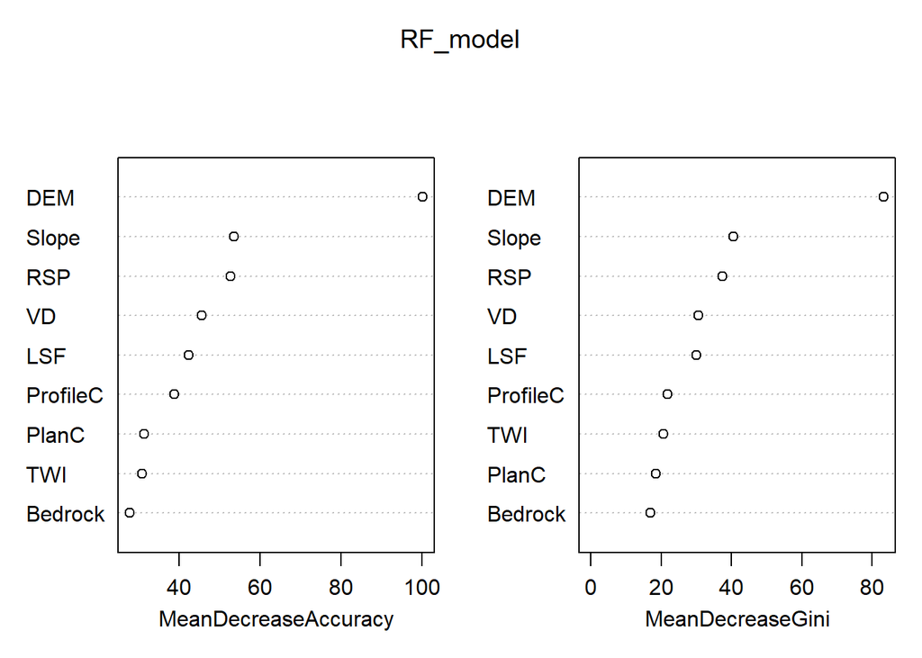

```r
sampleNum_dict[mn]<-nrow(sampData)

sampData$Bedrock<- droplevels(as.factor(sampData$Bedrock))
sampData$soilID<- droplevels(as.factor(sampData$soilID))

RF_model<-randomForest(soilID ~.,data = sampData,
                       importance = TRUE, proximity = FALSE,
                       ntree=1000,type="classification")

varImpPlot(RF_model)
```

```r
print(RF_model)
```

```
##
## Call:
##  randomForest(formula = soilID ~ ., data = sampData, importance = TRUE,      proximity = FALSE, ntree = 1000, type = "classification")
##                Type of random forest: classification
##                      Number of trees: 1000
## No. of variables tried at each split: 3
##
##         OOB estimate of  error rate: 21.19%
## Confusion matrix:
##     20 21 23  3 30 31 501 502 503  7 class.error
## 20  28  5  0  0  0  0   0   0   7  8  0.41666667
## 21  10  8  0  0  0  0   0   1   3  0  0.63636364
## 23   0  0 26  0  1  1   0   0   1  1  0.13333333
## 3    0  0  0 19  0  0   1   0   0  0  0.05000000
## 30   0  0  5  0  2  0   0   0   0  1  0.75000000
## 31   0  0  1  0  0 12   0   0   0  0  0.07692308
## 501  0  0  0  1  0  0  65   0   0  0  0.01515152
## 502  1  2  0  0  0  0   3   1   0  1  0.87500000
## 503  1  0  1  0  0  0   0   0  78  6  0.09302326
## 7    3  0  0  0  0  0   0   0  10 40  0.24528302
```

```r
map_RF <- predict(covStack, RF_model, paste(result_tif_folder,mn,".tif",sep=""),
                  format = "GTiff", datatype = "FLT4S", overwrite = TRUE)

rm("mn","shpPoint","sampData","RF_model","map_RF")
```

RAN DEM ns5 15

```r
mn="All_pRAN_DEM_NS5_pen15"

shpPoint<-readOGR(paste(point_shp_folder,mn,".shp",sep = "")) ###
sampData <- extract(covStack, shpPoint, sp = TRUE,method = "simple")

sampData<-sampData@data

sampData<-sampData[sampData$soilID %in% soil_type,]

sampData<-na.omit(sampData)

print(dim(sampData))
```

```
## [1] 356  10
```

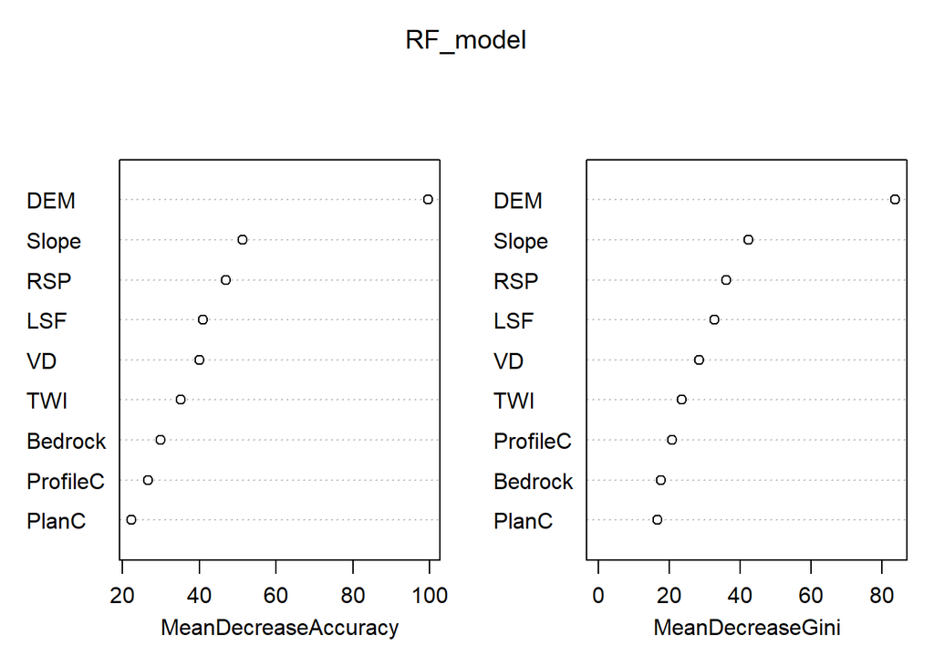

```r
sampleNum_dict[mn]<-nrow(sampData)

sampData$Bedrock<- droplevels(as.factor(sampData$Bedrock))
sampData$soilID<- droplevels(as.factor(sampData$soilID))

RF_model<-randomForest(soilID ~.,data = sampData,
                       importance = TRUE, proximity = FALSE,
                       ntree=1000,type="classification")

varImpPlot(RF_model)
```

```r
print(RF_model)
```

```
##
## Call:
##  randomForest(formula = soilID ~ ., data = sampData, importance = TRUE,      proximity = FALSE, ntree = 1000, type = "classification")
##                Type of random forest: classification
##                      Number of trees: 1000
## No. of variables tried at each split: 3
##
##         OOB estimate of  error rate: 25.84%
## Confusion matrix:
##     1 20 21 23  3 30 31 501 502 503  7 class.error
## 1   0  0  0  0  2  0  0   0   0   0  0  1.00000000
## 20  0 29  4  0  0  0  0   0   1   9  5  0.39583333
## 21  0 10  9  0  0  0  0   0   0   3  0  0.59090909
## 23  0  0  0 20  0  4  1   0   0   4  1  0.33333333
## 3   0  0  0  0 16  0  0   4   0   0  0  0.20000000
## 30  0  0  0  3  0  4  0   0   0   0  1  0.50000000
## 31  0  0  0  2  0  0 11   0   0   0  0  0.15384615
## 501 0  0  0  0  5  0  0  60   0   0  1  0.09090909
## 502 0  4  0  0  0  0  0   3   1   0  0  0.87500000
## 503 0  5  0  4  0  0  0   0   0  75  2  0.12790698
## 7   0  6  0  0  0  1  0   3   0   4 39  0.26415094
```

```r
map_RF <- predict(covStack, RF_model, paste(result_tif_folder,mn,".tif",sep=""),
                  format = "GTiff", datatype = "FLT4S", overwrite = TRUE)

rm("mn","shpPoint","sampData","RF_model","map_RF")
```

SNA DEM ns5 30

```r
mn="All_pSNA_DEM_NS5_pen30"

shpPoint<-readOGR(paste(point_shp_folder,mn,".shp",sep = "")) ###
sampData <- extract(covStack, shpPoint, sp = TRUE,method = "simple")

sampData<-sampData@data

sampData<-sampData[sampData$soilID %in% soil_type,]

sampData<-na.omit(sampData)

print(dim(sampData))
```

```
## [1] 677  10
```

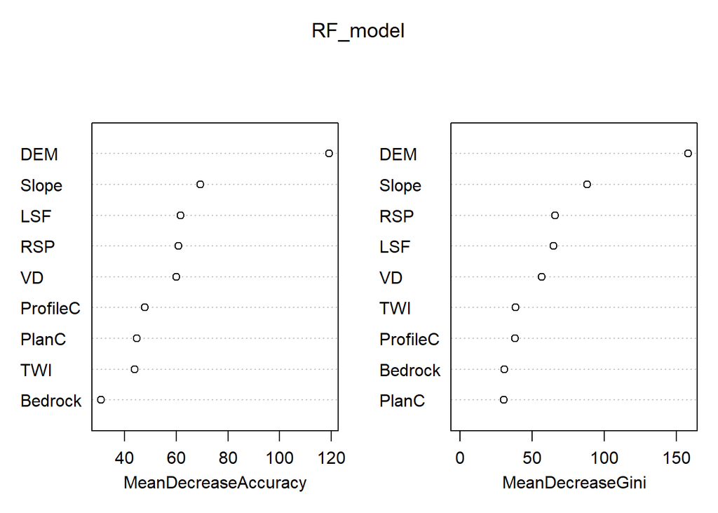

```r
sampleNum_dict[mn]<-nrow(sampData)

sampData$Bedrock<- droplevels(as.factor(sampData$Bedrock))
sampData$soilID<- droplevels(as.factor(sampData$soilID))

RF_model<-randomForest(soilID ~.,data = sampData,
                       importance = TRUE, proximity = FALSE,
                       ntree=1000,type="classification")

varImpPlot(RF_model)
```

```r
print(RF_model)
```

```
##
## Call:
##  randomForest(formula = soilID ~ ., data = sampData, importance = TRUE,      proximity = FALSE, ntree = 1000, type = "classification")
##                Type of random forest: classification
##                      Number of trees: 1000
## No. of variables tried at each split: 3
##
##         OOB estimate of  error rate: 16.25%
## Confusion matrix:
##     1 20 21 23  3 30 31 501 502 503  7 class.error
## 1   1  0  0  0  1  0  0   0   0   0  0  0.50000000
## 20  0 62  5  0  0  0  0   0   0  10 13  0.31111111
## 21  0 13 18  0  0  0  0   0   0   2  0  0.45454545
## 23  0  0  0 48  0  2  1   0   0   1  3  0.12727273
## 3   0  0  0  0 38  0  0   2   0   0  0  0.05000000
## 30  0  0  0 12  0  3  0   0   0   0  0  0.80000000
## 31  0  0  0  1  0  0 25   0   0   0  0  0.03846154
## 501 0  0  0  0  2  0  0 129   0   0  0  0.01526718
## 502 0  3  2  0  0  0  0   6   3   0  1  0.80000000
## 503 0  4  0  2  0  0  0   0   0 155  5  0.06626506
## 7   0  7  0  1  0  0  0   1   0  10 85  0.18269231
```

```r
map_RF <- predict(covStack, RF_model, paste(result_tif_folder,mn,".tif",sep=""),
                  format = "GTiff", datatype = "FLT4S", overwrite = TRUE)

rm("mn","shpPoint","sampData","RF_model","map_RF")
```

RAN DEM ns5 30

```r
mn="All_pRAN_DEM_NS5_pen30"

shpPoint<-readOGR(paste(point_shp_folder,mn,".shp",sep = "")) ###
sampData <- extract(covStack, shpPoint, sp = TRUE,method = "simple")

sampData<-sampData@data

sampData<-sampData[sampData$soilID %in% soil_type,]

sampData<-na.omit(sampData)

print(dim(sampData))
```

```
## [1] 679  10
```

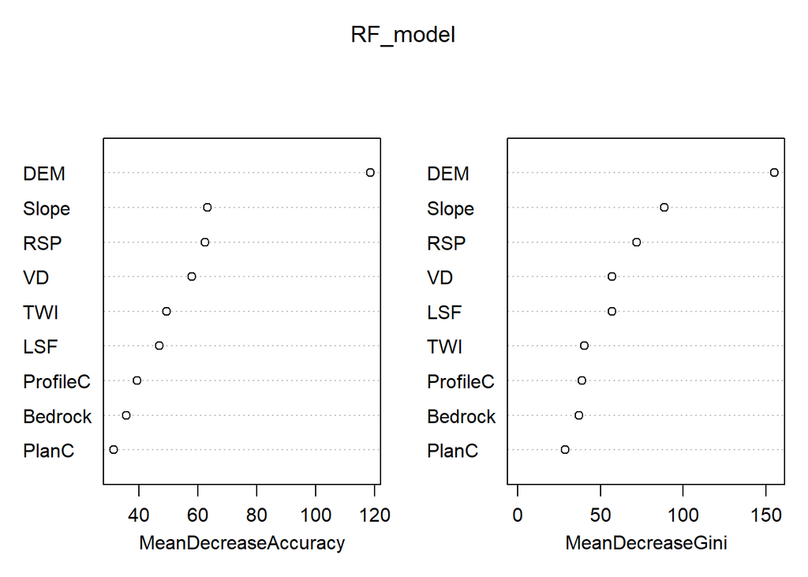

```r
sampleNum_dict[mn]<-nrow(sampData)

sampData$Bedrock<- droplevels(as.factor(sampData$Bedrock))
sampData$soilID<- droplevels(as.factor(sampData$soilID))

RF_model<-randomForest(soilID ~.,data = sampData,
                       importance = TRUE, proximity = FALSE,
                       ntree=1000,type="classification")

varImpPlot(RF_model)
```

```r
print(RF_model)
```

```
##
## Call:
##  randomForest(formula = soilID ~ ., data = sampData, importance = TRUE,      proximity = FALSE, ntree = 1000, type = "classification")
##                Type of random forest: classification
##                      Number of trees: 1000
## No. of variables tried at each split: 3
##
##         OOB estimate of  error rate: 20.18%
## Confusion matrix:
##     1 20 21 23  3 30 31 501 502 503  7 class.error
## 1   2  0  0  0  2  0  0   0   0   0  0  0.50000000
## 20  0 57  9  0  0  0  0   2   1  10 11  0.36666667
## 21  0 14 18  0  0  0  0   0   0   1  0  0.45454545
## 23  0  0  0 40  0  4  1   0   0   7  3  0.27272727
## 3   1  0  0  0 34  0  0   5   0   0  0  0.15000000
## 30  0  0  0  8  0  5  2   0   0   0  0  0.66666667
## 31  0  0  0  7  0  0 19   0   0   0  0  0.26923077
## 501 0  1  0  0  5  0  0 124   0   0  1  0.05343511
## 502 0  3  1  0  0  0  0   1   8   1  1  0.46666667
## 503 0  8  0  3  0  0  0   0   0 152  3  0.08433735
## 7   0  9  0  2  0  0  0   4   0   6 83  0.20192308
```

```r
map_RF <- predict(covStack, RF_model, paste(result_tif_folder,mn,".tif",sep=""),
                  format = "GTiff", datatype = "FLT4S", overwrite = TRUE)

rm("mn","shpPoint","sampData","RF_model","map_RF")
```

SNA DEM ns5 45

```r
mn="All_pSNA_DEM_NS5_pen45"

shpPoint<-readOGR(paste(point_shp_folder,mn,".shp",sep = "")) ###
sampData <- extract(covStack, shpPoint, sp = TRUE,method = "simple")

sampData<-sampData@data

sampData<-sampData[sampData$soilID %in% soil_type,]

sampData<-na.omit(sampData)

print(dim(sampData))
```

```
## [1] 993  10
```

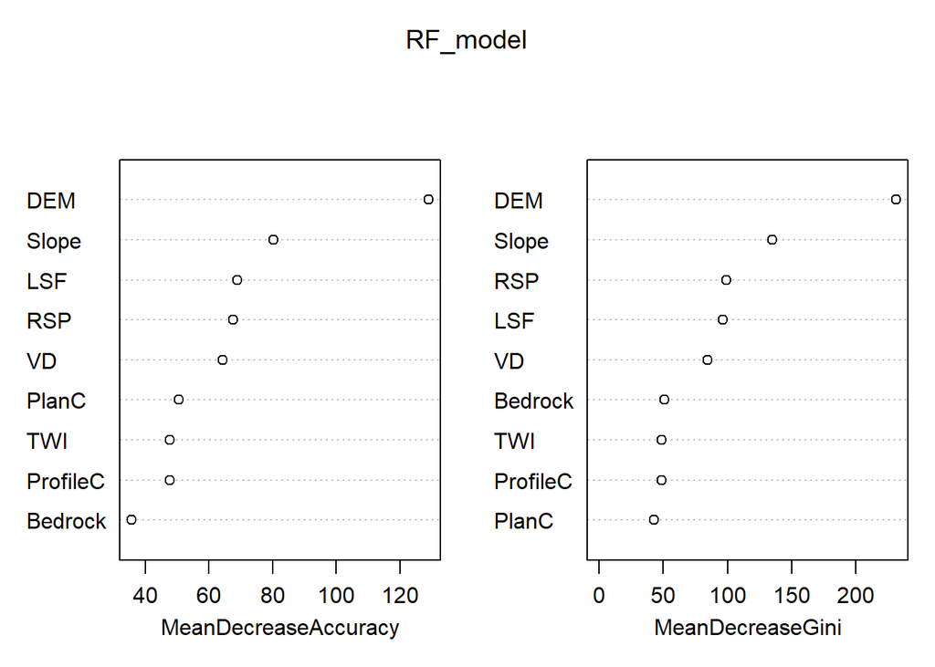

```r
sampleNum_dict[mn]<-nrow(sampData)

sampData$Bedrock<- droplevels(as.factor(sampData$Bedrock))
sampData$soilID<- droplevels(as.factor(sampData$soilID))

RF_model<-randomForest(soilID ~.,data = sampData,
                       importance = TRUE, proximity = FALSE,
                       ntree=1000,type="classification")

varImpPlot(RF_model)
```

```r
print(RF_model)
```

```
##
## Call:
##  randomForest(formula = soilID ~ ., data = sampData, importance = TRUE,      proximity = FALSE, ntree = 1000, type = "classification")
##                Type of random forest: classification
##                      Number of trees: 1000
## No. of variables tried at each split: 3
##
##         OOB estimate of  error rate: 16.21%
## Confusion matrix:
##     1 20 21 23  3 30 31 501 502 503   7 class.error
## 1   4  0  0  0  0  0  0   0   0   0   0  0.00000000
## 20  0 91  9  0  0  0  0   0   0  13  15  0.28906250
## 21  0 16 28  0  0  0  0   0   0   1   0  0.37777778
## 23  0  0  0 73  0  5  1   0   0   3   1  0.12048193
## 3   0  0  0  0 54  0  0   5   0   0   0  0.08474576
## 30  0  0  0 14  0  5  0   0   0   0   0  0.73684211
## 31  0  0  0  2  0  0 37   0   0   0   0  0.05128205
## 501 0  0  0  0  6  0  0 191   0   0   0  0.03045685
## 502 0  4  2  0  0  0  0   9   5   0   2  0.77272727
## 503 0 10  0  2  0  0  0   0   0 227   9  0.08467742
## 7   0 11  0  1  0  0  0   2   0  18 117  0.21476510
```

```r
map_RF <- predict(covStack, RF_model, paste(result_tif_folder,mn,".tif",sep=""),
                  format = "GTiff", datatype = "FLT4S", overwrite = TRUE)

rm("mn","shpPoint","sampData","RF_model","map_RF")
```

RAN DEM ns5 45

```r
mn="All_pRAN_DEM_NS5_pen45"

shpPoint<-readOGR(paste(point_shp_folder,mn,".shp",sep = "")) ###
sampData <- extract(covStack, shpPoint, sp = TRUE,method = "simple")

sampData<-sampData@data

sampData<-sampData[sampData$soilID %in% soil_type,]

sampData<-na.omit(sampData)

print(dim(sampData))
```

```
## [1] 995  10
```

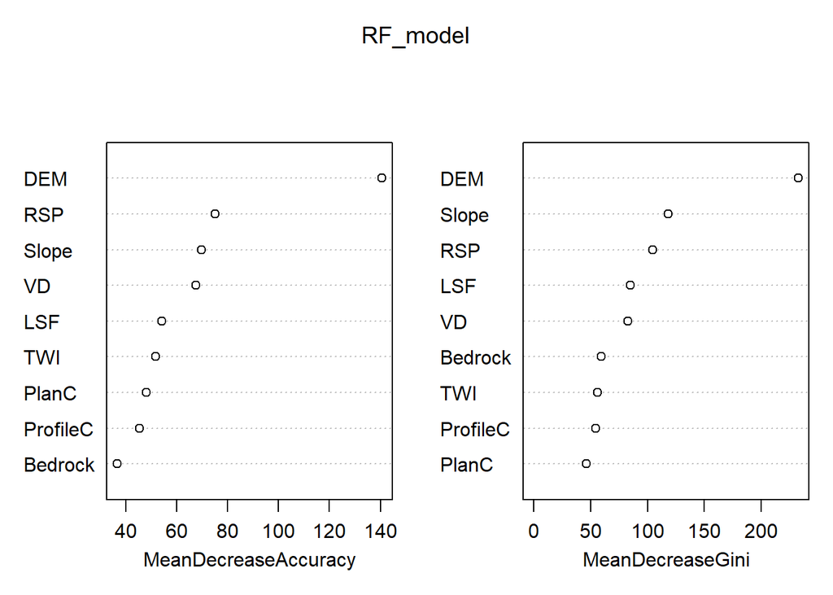

```r
sampleNum_dict[mn]<-nrow(sampData)

sampData$Bedrock<- droplevels(as.factor(sampData$Bedrock))
sampData$soilID<- droplevels(as.factor(sampData$soilID))

RF_model<-randomForest(soilID ~.,data = sampData,
                       importance = TRUE, proximity = FALSE,
                       ntree=1000,type="classification")

varImpPlot(RF_model)
```

```r
print(RF_model)
```

```
##
## Call:
##  randomForest(formula = soilID ~ ., data = sampData, importance = TRUE,      proximity = FALSE, ntree = 1000, type = "classification")
##                Type of random forest: classification
##                      Number of trees: 1000
## No. of variables tried at each split: 3
##
##         OOB estimate of  error rate: 17.99%
## Confusion matrix:
##     1 20 21 23  3 30 31 501 502 503   7 class.error
## 1   5  0  0  0  1  0  0   0   0   0   0  0.16666667
## 20  0 86 10  0  0  0  0   1   2  18  11  0.32812500
## 21  0 15 26  0  0  0  0   0   2   2   0  0.42222222
## 23  0  0  0 57  0  8  1   0   0  14   3  0.31325301
## 3   1  0  0  0 45  0  0  13   0   0   0  0.23728814
## 30  0  0  0  7  0  8  2   0   0   0   2  0.57894737
## 31  0  0  0  1  0  1 37   0   0   0   0  0.05128205
## 501 0  2  0  0  7  0  0 187   0   0   1  0.05076142
## 502 0  4  2  0  0  0  0   0  15   0   1  0.31818182
## 503 0 13  1  6  0  0  0   0   0 224   4  0.09677419
## 7   0  9  0  2  0  3  0   3   1   5 126  0.15436242
```

```r
map_RF <- predict(covStack, RF_model, paste(result_tif_folder,mn,".tif",sep=""),
                  format = "GTiff", datatype = "FLT4S", overwrite = TRUE)

rm("mn","shpPoint","sampData","RF_model","map_RF")
```

SNA DEM ns5 60

```r
mn="All_pSNA_DEM_NS5_pen60"

shpPoint<-readOGR(paste(point_shp_folder,mn,".shp",sep = "")) ###
sampData <- extract(covStack, shpPoint, sp = TRUE,method = "simple")

sampData<-sampData@data

sampData<-sampData[sampData$soilID %in% soil_type,]

sampData<-na.omit(sampData)

print(dim(sampData))
```

```
## [1] 1318   10
```

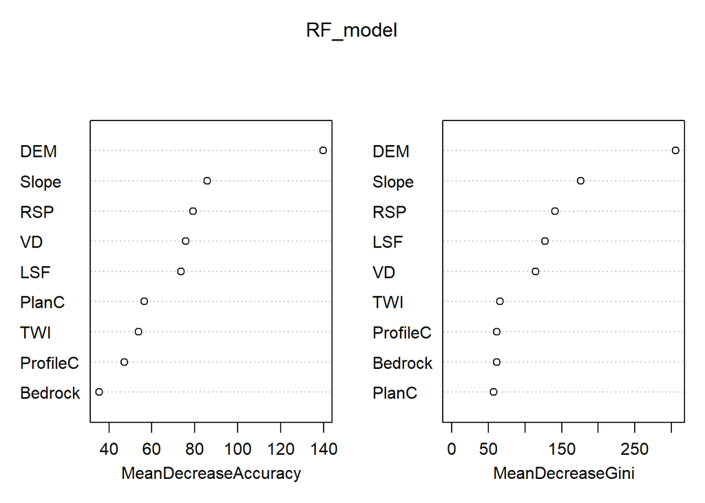

```r
sampleNum_dict[mn]<-nrow(sampData)

sampData$Bedrock<- droplevels(as.factor(sampData$Bedrock))
sampData$soilID<- droplevels(as.factor(sampData$soilID))

RF_model<-randomForest(soilID ~.,data = sampData,
                       importance = TRUE, proximity = FALSE,
                       ntree=1000,type="classification")

varImpPlot(RF_model)
```

```r
print(RF_model)
```

```
##
## Call:
##  randomForest(formula = soilID ~ ., data = sampData, importance = TRUE,      proximity = FALSE, ntree = 1000, type = "classification")
##                Type of random forest: classification
##                      Number of trees: 1000
## No. of variables tried at each split: 3
##
##         OOB estimate of  error rate: 16.54%
## Confusion matrix:
##     1  20 21 23  3 30 31 501 502 503   7 class.error
## 1   4   0  0  0  2  0  0   0   0   0   0  0.33333333
## 20  0 124 11  0  0  0  0   0   1  16  18  0.27058824
## 21  0  18 40  0  0  0  0   0   0   1   0  0.32203390
## 23  0   0  0 92  0 10  2   0   0   2   3  0.15596330
## 3   1   0  0  0 71  0  0   7   0   0   0  0.10126582
## 30  0   0  0 17  0  8  0   0   0   0   1  0.69230769
## 31  0   0  0  3  0  0 49   0   0   0   0  0.05769231
## 501 0   0  0  0 10  0  0 251   0   0   1  0.04198473
## 502 0   2  2  0  0  0  0   7  14   0   3  0.50000000
## 503 0  18  0  6  0  0  0   0   0 292  12  0.10975610
## 7   0  16  0  2  0  0  0   3   2  21 155  0.22110553
```

```r
map_RF <- predict(covStack, RF_model, paste(result_tif_folder,mn,".tif",sep=""),
                  format = "GTiff", datatype = "FLT4S", overwrite = TRUE)

rm("mn","shpPoint","sampData","RF_model","map_RF")
```

RAN DEM ns5 60

```r
mn="All_pRAN_DEM_NS5_pen60"

shpPoint<-readOGR(paste(point_shp_folder,mn,".shp",sep = "")) ###
sampData <- extract(covStack, shpPoint, sp = TRUE,method = "simple")

sampData<-sampData@data

sampData<-sampData[sampData$soilID %in% soil_type,]

sampData<-na.omit(sampData)

print(dim(sampData))
```

```
## [1] 1320   10
```

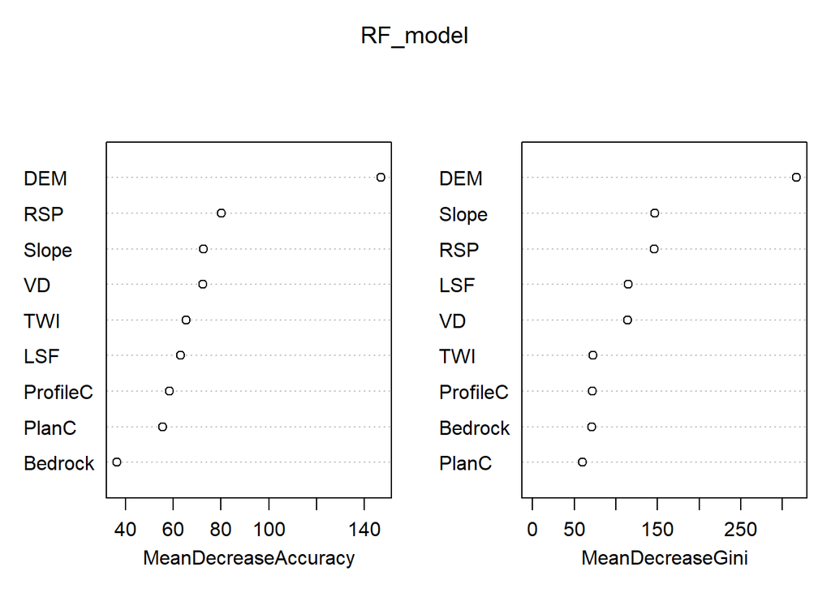

```r
sampleNum_dict[mn]<-nrow(sampData)

sampData$Bedrock<- droplevels(as.factor(sampData$Bedrock))
sampData$soilID<- droplevels(as.factor(sampData$soilID))

RF_model<-randomForest(soilID ~.,data = sampData,
                       importance = TRUE, proximity = FALSE,
                       ntree=1000,type="classification")

varImpPlot(RF_model)
```

```r
print(RF_model)
```

```
##
## Call:
##  randomForest(formula = soilID ~ ., data = sampData, importance = TRUE,      proximity = FALSE, ntree = 1000, type = "classification")
##                Type of random forest: classification
##                      Number of trees: 1000
## No. of variables tried at each split: 3
##
##         OOB estimate of  error rate: 16.74%
## Confusion matrix:
##     1  20 21 23  3 30 31 501 502 503   7 class.error
## 1   5   0  0  0  3  0  0   0   0   0   0  0.37500000
## 20  0 126  8  0  0  0  0   3   2  17  14  0.25882353
## 21  0  20 36  0  0  0  0   0   2   1   0  0.38983051
## 23  0   0  0 77  0  7  5   0   0  17   3  0.29357798
## 3   2   0  0  0 63  0  0  14   0   0   0  0.20253165
## 30  0   0  0 10  0 11  5   0   0   0   0  0.57692308
## 31  0   0  0  1  0  2 48   0   0   1   0  0.07692308
## 501 0   1  0  0  6  0  0 251   0   0   4  0.04198473
## 502 0   1  2  0  0  0  0   3  19   1   2  0.32142857
## 503 0  12  2 11  0  0  0   0   1 294   8  0.10365854
## 7   0  14  0  3  0  1  0   4   1   7 169  0.15075377
```

```r
map_RF <- predict(covStack, RF_model, paste(result_tif_folder,mn,".tif",sep=""),
                  format = "GTiff", datatype = "FLT4S", overwrite = TRUE)

rm("mn","shpPoint","sampData","RF_model","map_RF")
```

SNA DEM ns5 75

```r
mn="All_pSNA_DEM_NS5_pen75"

shpPoint<-readOGR(paste(point_shp_folder,mn,".shp",sep = "")) ###
sampData <- extract(covStack, shpPoint, sp = TRUE,method = "simple")

sampData<-sampData@data

sampData<-sampData[sampData$soilID %in% soil_type,]

sampData<-na.omit(sampData)

print(dim(sampData))
```

```
## [1] 1637   10
```

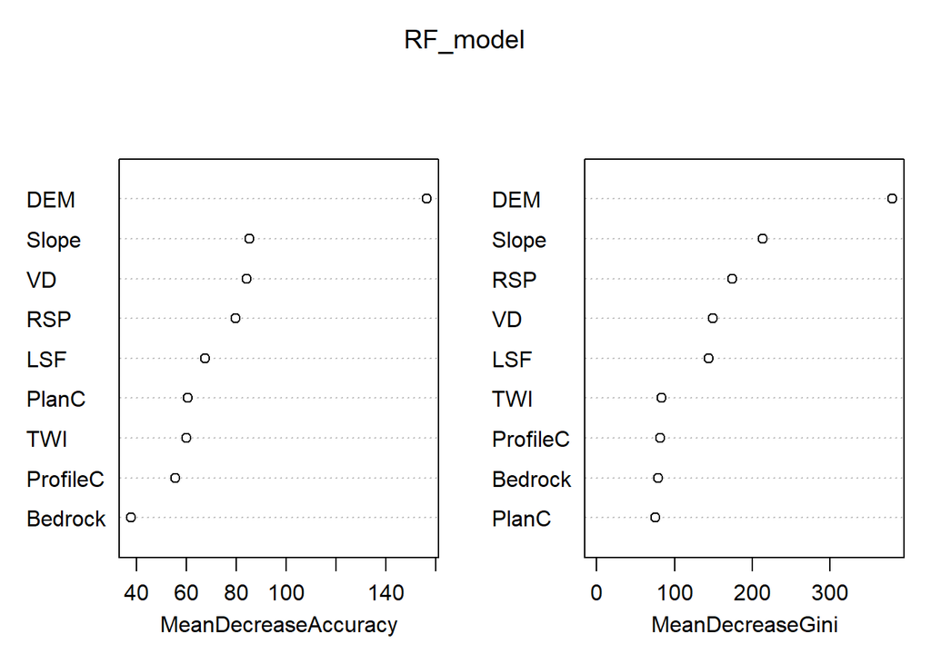

```r
sampleNum_dict[mn]<-nrow(sampData)

sampData$Bedrock<- droplevels(as.factor(sampData$Bedrock))
sampData$soilID<- droplevels(as.factor(sampData$soilID))

RF_model<-randomForest(soilID ~.,data = sampData,
                       importance = TRUE, proximity = FALSE,
                       ntree=1000,type="classification")

varImpPlot(RF_model)
```

```r
print(RF_model)
```

```
##
## Call:
##  randomForest(formula = soilID ~ ., data = sampData, importance = TRUE,      proximity = FALSE, ntree = 1000, type = "classification")
##                Type of random forest: classification
##                      Number of trees: 1000
## No. of variables tried at each split: 3
##
##         OOB estimate of  error rate: 16.68%
## Confusion matrix:
##     1  20 21  23  3 30 31 501 502 503   7 class.error
## 1   6   0  0   0  2  0  0   0   0   0   0  0.25000000
## 20  0 156  9   0  0  0  0   0   1  21  22  0.25358852
## 21  0  22 46   0  0  0  0   0   0   1   0  0.33333333
## 23  0   0  0 107  0 10  2   0   0  10   8  0.21897810
## 3   1   0  0   0 85  0  0  13   0   0   0  0.14141414
## 30  0   0  0  15  0 17  1   0   0   0   1  0.50000000
## 31  0   0  0   6  0  0 58   0   0   0   0  0.09375000
## 501 0   0  0   0 17  0  0 309   0   0   2  0.05792683
## 502 0   2  2   0  0  0  0   5  21   1   3  0.38235294
## 503 0  21  1  11  0  0  0   0   0 365  12  0.10975610
## 7   0  19  0   7  0  0  0   3   2  20 194  0.20816327
```

```r
map_RF <- predict(covStack, RF_model, paste(result_tif_folder,mn,".tif",sep=""),
                  format = "GTiff", datatype = "FLT4S", overwrite = TRUE)

rm("mn","shpPoint","sampData","RF_model","map_RF")
```

RAN DEM ns5 75

```r
mn="All_pRAN_DEM_NS5_pen75"

shpPoint<-readOGR(paste(point_shp_folder,mn,".shp",sep = "")) ###
sampData <- extract(covStack, shpPoint, sp = TRUE,method = "simple")

sampData<-sampData@data

sampData<-sampData[sampData$soilID %in% soil_type,]

sampData<-na.omit(sampData)

print(dim(sampData))
```

```
## [1] 1639   10
```

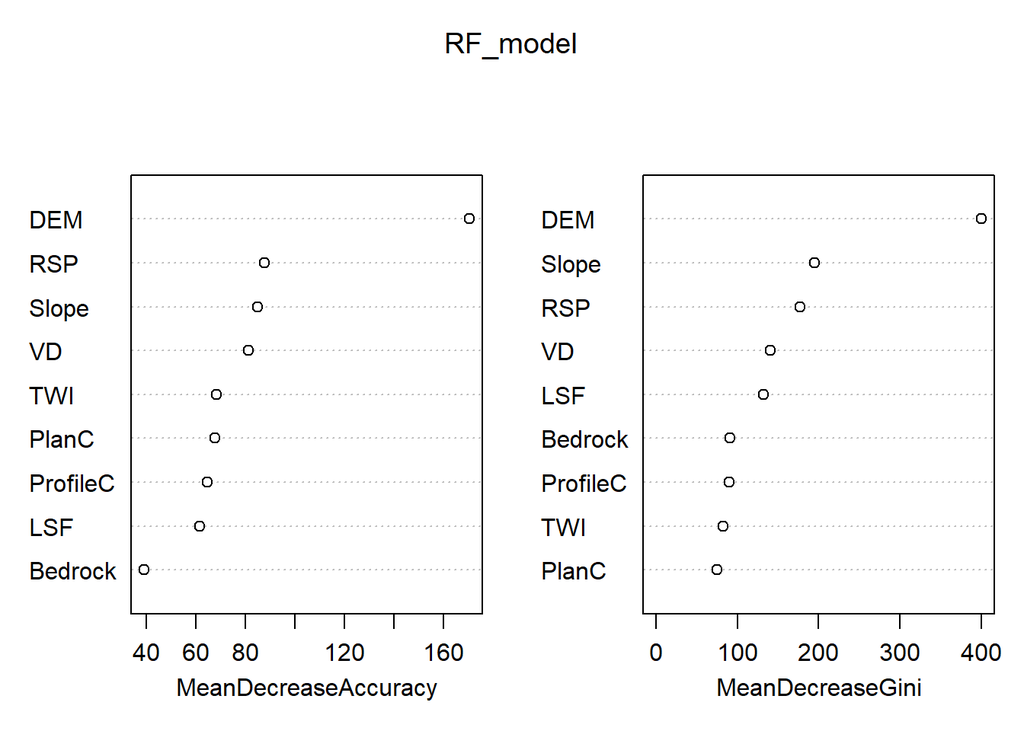

```r
sampleNum_dict[mn]<-nrow(sampData)

sampData$Bedrock<- droplevels(as.factor(sampData$Bedrock))
sampData$soilID<- droplevels(as.factor(sampData$soilID))

RF_model<-randomForest(soilID ~.,data = sampData,
                       importance = TRUE, proximity = FALSE,
                       ntree=1000,type="classification")

varImpPlot(RF_model)
```

```r
print(RF_model)
```

```
##
## Call:
##  randomForest(formula = soilID ~ ., data = sampData, importance = TRUE,      proximity = FALSE, ntree = 1000, type = "classification")
##                Type of random forest: classification
##                      Number of trees: 1000
## No. of variables tried at each split: 3
##
##         OOB estimate of  error rate: 14.7%
## Confusion matrix:
##     1  20 21  23  3 30 31 501 502 503   7 class.error
## 1   7   0  0   0  3  0  0   0   0   0   0  0.30000000
## 20  0 157  7   0  0  0  0   1   1  22  21  0.24880383
## 21  0  24 39   0  0  0  0   0   2   3   1  0.43478261
## 23  0   0  0 107  0  9  2   0   0  15   4  0.21897810
## 3   1   0  0   0 84  0  0  14   0   0   0  0.15151515
## 30  0   0  0   9  0 20  3   0   0   0   2  0.41176471
## 31  0   0  0   3  0  1 59   0   0   1   0  0.07812500
## 501 0   2  0   0 14  0  0 309   0   0   3  0.05792683
## 502 0   1  1   0  0  0  0   0  31   0   1  0.08823529
## 503 0  11  4   9  0  0  0   0   0 378   8  0.07804878
## 7   0  16  0   3  0  1  0   7   1  10 207  0.15510204
```

```r
map_RF <- predict(covStack, RF_model, paste(result_tif_folder,mn,".tif",sep=""),
                  format = "GTiff", datatype = "FLT4S", overwrite = TRUE)

rm("mn","shpPoint","sampData","RF_model","map_RF")
```

# Slope

SNA Slope ns3 15

```r
mn="All_pSNA_Slope_NS3_pen15"

shpPoint<-readOGR(paste(point_shp_folder,mn,".shp",sep = "")) ###
sampData <- extract(covStack, shpPoint, sp = TRUE,method = "simple")

sampData<-sampData@data

sampData<-sampData[sampData$soilID %in% soil_type,]

sampData<-na.omit(sampData)

print(dim(sampData))
```

```
## [1] 994  10
```

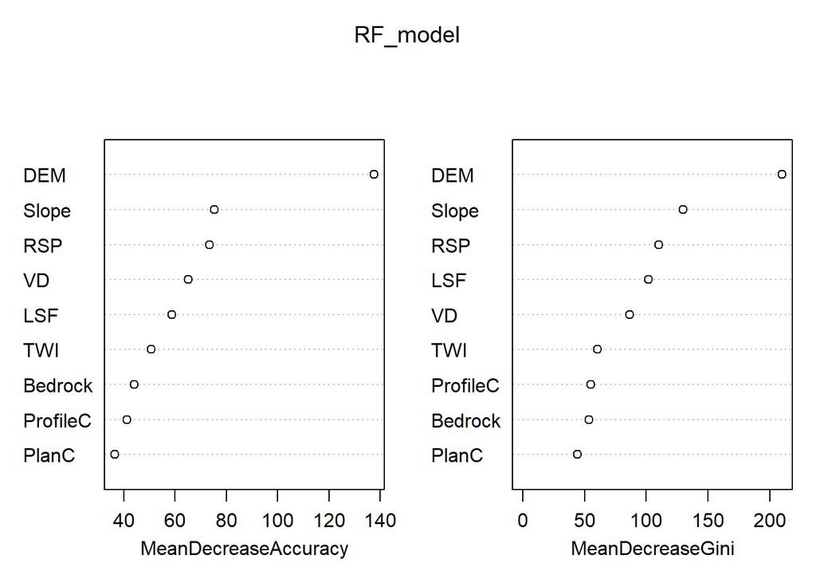

```r
sampleNum_dict[mn]<-nrow(sampData)

sampData$Bedrock<- droplevels(as.factor(sampData$Bedrock))
sampData$soilID<- droplevels(as.factor(sampData$soilID))

RF_model<-randomForest(soilID ~.,data = sampData,
                       importance = TRUE, proximity = FALSE,
                       ntree=1000,type="classification")

varImpPlot(RF_model)
```

```r
print(RF_model)
```

```
##
## Call:
##  randomForest(formula = soilID ~ ., data = sampData, importance = TRUE,      proximity = FALSE, ntree = 1000, type = "classification")
##                Type of random forest: classification
##                      Number of trees: 1000
## No. of variables tried at each split: 3
##
##         OOB estimate of  error rate: 21.33%
## Confusion matrix:
##     1  20 21 23  3 30 31 501 502 503   7 class.error
## 1   2   0  0  0  2  0  0   0   0   0   0  0.50000000
## 20  0 104 13  0  0  0  0   1   1  17  19  0.32903226
## 21  0  24 31  0  0  0  0   0   1   3   0  0.47457627
## 23  0   0  0 79  0  4  5   0   0  12   0  0.21000000
## 3   2   0  0  0 39  0  0  11   0   0   0  0.25000000
## 30  0   1  0  7  0 22  2   0   0   0   1  0.33333333
## 31  0   0  0  3  0  0 38   0   0   0   0  0.07317073
## 501 0   2  0  0  8  0  0 146   1   0   2  0.08176101
## 502 0   5  0  0  0  0  0   0  15   0   2  0.31818182
## 503 0  15  0 11  0  1  0   0   0 197   4  0.13596491
## 7   0  15  0  0  0  3  0   6   1   7 109  0.22695035
```

```r
map_RF <- predict(covStack, RF_model, paste(result_tif_folder,mn,".tif",sep=""),
                  format = "GTiff", datatype = "FLT4S", overwrite = TRUE)

rm("mn","shpPoint","sampData","RF_model","map_RF")
```

RAN Slope ns3 15

```r
mn="All_pRAN_Slope_NS3_pen15"

shpPoint<-readOGR(paste(point_shp_folder,mn,".shp",sep = "")) ###
sampData <- extract(covStack, shpPoint, sp = TRUE,method = "simple")

sampData<-sampData@data

sampData<-sampData[sampData$soilID %in% soil_type,]

sampData<-na.omit(sampData)

print(dim(sampData))
```

```
## [1] 996  10
```

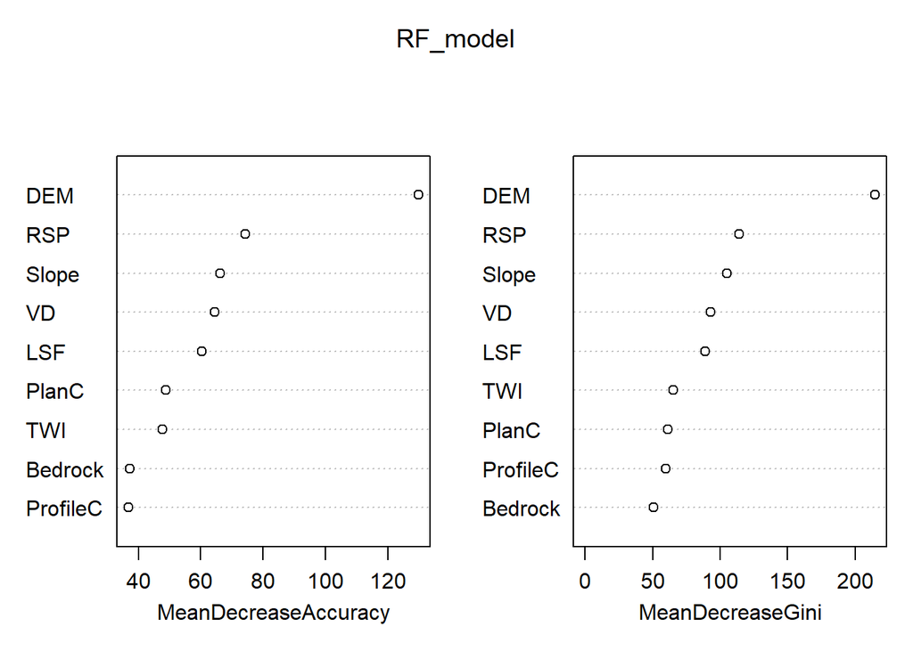

```r
sampleNum_dict[mn]<-nrow(sampData)

sampData$Bedrock<- droplevels(as.factor(sampData$Bedrock))
sampData$soilID<- droplevels(as.factor(sampData$soilID))

RF_model<-randomForest(soilID ~.,data = sampData,
                       importance = TRUE, proximity = FALSE,
                       ntree=1000,type="classification")

varImpPlot(RF_model)
```

```r
print(RF_model)
```

```
##
## Call:
##  randomForest(formula = soilID ~ ., data = sampData, importance = TRUE,      proximity = FALSE, ntree = 1000, type = "classification")
##                Type of random forest: classification
##                      Number of trees: 1000
## No. of variables tried at each split: 3
##
##         OOB estimate of  error rate: 27.61%
## Confusion matrix:
##     1  20 21 23  3 30 31 501 502 503   7 class.error
## 1   6   0  0  0  0  0  0   0   0   0   0  0.00000000
## 20  0 103 13  0  0  0  0   3   0  22  14  0.33548387
## 21  0  31 21  0  0  0  0   0   0   5   2  0.64406780
## 23  0   0  0 69  0 10  3   0   0  15   3  0.31000000
## 3   0   0  0  0 41  0  0  11   0   0   0  0.21153846
## 30  0   0  0  9  0 16  4   0   0   2   2  0.51515152
## 31  0   0  0  9  0  4 28   0   0   0   0  0.31707317
## 501 0   2  0  0  8  0  0 145   0   0   4  0.08805031
## 502 0   6  0  0  0  0  0   3  12   0   1  0.45454545
## 503 0  18  5 16  0  1  0   0   0 175  13  0.23245614
## 7   0  14  0  2  0  3  0   7   2   8 105  0.25531915
```

```r
map_RF <- predict(covStack, RF_model, paste(result_tif_folder,mn,".tif",sep=""),
                  format = "GTiff", datatype = "FLT4S", overwrite = TRUE)

rm("mn","shpPoint","sampData","RF_model","map_RF")
```

SNA Slope ns3 30

```r
mn="All_pSNA_Slope_NS3_pen30"

shpPoint<-readOGR(paste(point_shp_folder,mn,".shp",sep = "")) ###
sampData <- extract(covStack, shpPoint, sp = TRUE,method = "simple")

sampData<-sampData@data

sampData<-sampData[sampData$soilID %in% soil_type,]

sampData<-na.omit(sampData)

print(dim(sampData))
```

```
## [1] 1947   10
```

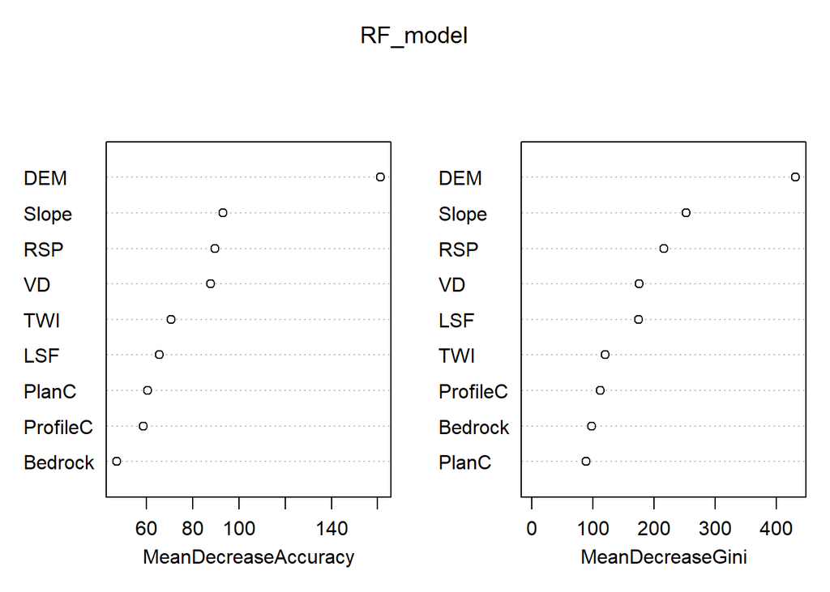

```r
sampleNum_dict[mn]<-nrow(sampData)

sampData$Bedrock<- droplevels(as.factor(sampData$Bedrock))
sampData$soilID<- droplevels(as.factor(sampData$soilID))

RF_model<-randomForest(soilID ~.,data = sampData,
                       importance = TRUE, proximity = FALSE,
                       ntree=1000,type="classification")

varImpPlot(RF_model)
```

```r
print(RF_model)
```

```
##
## Call:
##  randomForest(formula = soilID ~ ., data = sampData, importance = TRUE,      proximity = FALSE, ntree = 1000, type = "classification")
##                Type of random forest: classification
##                      Number of trees: 1000
## No. of variables tried at each split: 3
##
##         OOB estimate of  error rate: 19.31%
## Confusion matrix:
##     1  20 21  23  3 30 31 501 502 503   7 class.error
## 1   7   0  0   0  3  0  0   0   0   0   0  0.30000000
## 20  0 213 14   0  0  0  0   3   0  42  31  0.29702970
## 21  0  39 64   0  0  0  0   0   3   5   0  0.42342342
## 23  0   1  0 153  0 10  5   0   0  20   2  0.19895288
## 3   1   0  0   0 85  0  0  18   0   0   0  0.18269231
## 30  0   1  0   6  0 52  1   0   0   0   3  0.17460317
## 31  0   0  0   2  0  1 79   0   0   0   0  0.03658537
## 501 0   1  0   0 12  0  0 290   0   1  13  0.08517350
## 502 0   7  2   0  0  0  0   0  27   2   3  0.34146341
## 503 0  31  3  18  0  1  0   0   2 384  10  0.14476615
## 7   0  27  0   1  0  2  0  13   1  15 217  0.21376812
```

```r
map_RF <- predict(covStack, RF_model, paste(result_tif_folder,mn,".tif",sep=""),
                  format = "GTiff", datatype = "FLT4S", overwrite = TRUE)

rm("mn","shpPoint","sampData","RF_model","map_RF")
```

RAN Slope ns3 30

```r
mn="All_pRAN_Slope_NS3_pen30"

shpPoint<-readOGR(paste(point_shp_folder,mn,".shp",sep = "")) ###
sampData <- extract(covStack, shpPoint, sp = TRUE,method = "simple")

sampData<-sampData@data

sampData<-sampData[sampData$soilID %in% soil_type,]

sampData<-na.omit(sampData)

print(dim(sampData))
```

```
## [1] 1948   10
```

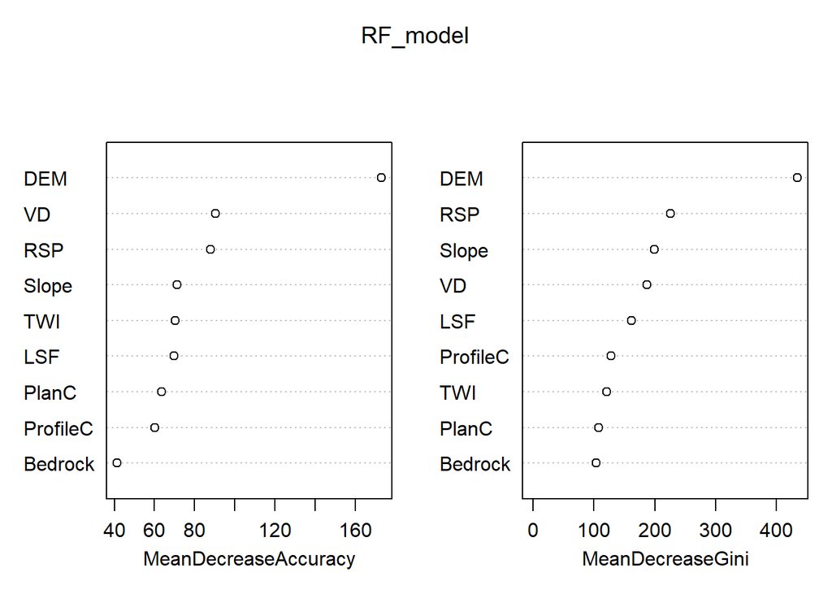

```r
sampleNum_dict[mn]<-nrow(sampData)

sampData$Bedrock<- droplevels(as.factor(sampData$Bedrock))
sampData$soilID<- droplevels(as.factor(sampData$soilID))

RF_model<-randomForest(soilID ~.,data = sampData,
                       importance = TRUE, proximity = FALSE,
                       ntree=1000,type="classification")

varImpPlot(RF_model)
```

```r
print(RF_model)
```

```
##
## Call:
##  randomForest(formula = soilID ~ ., data = sampData, importance = TRUE,      proximity = FALSE, ntree = 1000, type = "classification")
##                Type of random forest: classification
##                      Number of trees: 1000
## No. of variables tried at each split: 3
##
##         OOB estimate of  error rate: 21.92%
## Confusion matrix:
##      1  20 21  23  3 30 31 501 502 503   7 class.error
## 1   11   0  0   0  0  0  0   0   0   0   0  0.00000000
## 20   0 200 24   0  0  0  0   3   1  46  29  0.33993399
## 21   0  39 58   0  0  0  0   0   2  12   0  0.47747748
## 23   0   0  0 146  0  8  8   0   0  21   8  0.23560209
## 3    1   0  0   0 76  0  0  27   0   0   0  0.26923077
## 30   0   0  0  16  0 43  3   0   0   0   1  0.31746032
## 31   0   0  0  10  0  5 67   0   0   0   0  0.18292683
## 501  0   4  0   0 13  0  0 291   1   0   8  0.08201893
## 502  0   3  3   0  0  0  0   2  28   0   5  0.31707317
## 503  0  30  5  20  0  2  0   0   0 378  14  0.15812918
## 7    0  26  0   1  0  1  0  11   4  10 223  0.19202899
```

```r
map_RF <- predict(covStack, RF_model, paste(result_tif_folder,mn,".tif",sep=""),
                  format = "GTiff", datatype = "FLT4S", overwrite = TRUE)

rm("mn","shpPoint","sampData","RF_model","map_RF")
```

SNA Slope ns3 45

```r
mn="All_pSNA_Slope_NS3_pen45"

shpPoint<-readOGR(paste(point_shp_folder,mn,".shp",sep = "")) ###
sampData <- extract(covStack, shpPoint, sp = TRUE,method = "simple")

sampData<-sampData@data

sampData<-sampData[sampData$soilID %in% soil_type,]

sampData<-na.omit(sampData)

print(dim(sampData))
```

```
## [1] 2885   10
```

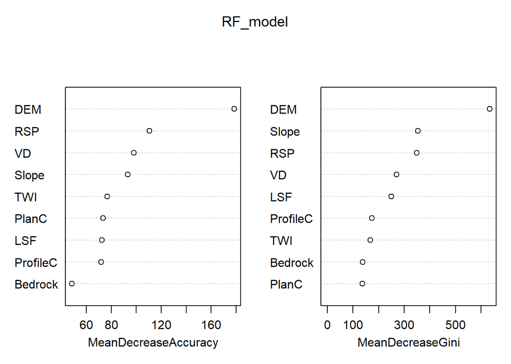

```r
sampleNum_dict[mn]<-nrow(sampData)

sampData$Bedrock<- droplevels(as.factor(sampData$Bedrock))
sampData$soilID<- droplevels(as.factor(sampData$soilID))

RF_model<-randomForest(soilID ~.,data = sampData,
                       importance = TRUE, proximity = FALSE,
                       ntree=1000,type="classification")

varImpPlot(RF_model)
```

```r
print(RF_model)
```

```
##
## Call:
##  randomForest(formula = soilID ~ ., data = sampData, importance = TRUE,      proximity = FALSE, ntree = 1000, type = "classification")
##                Type of random forest: classification
##                      Number of trees: 1000
## No. of variables tried at each split: 3
##
##         OOB estimate of  error rate: 18.82%
## Confusion matrix:
##      1  20 21  23   3 30  31 501 502 503   7 class.error
## 1   13   0  0   0   3  0   0   0   0   0   0  0.18750000
## 20   0 305 27   0   0  0   0   7   3  60  45  0.31767338
## 21   0  60 91   0   0  0   0   2   2   6   0  0.43478261
## 23   0   1  0 223   0 14   5   0   0  34   5  0.20921986
## 3    3   0  0   0 128  0   0  24   0   0   0  0.17419355
## 30   0   1  0  12   0 71   4   0   0   0   3  0.21978022
## 31   0   0  0   9   0  3 111   0   0   0   0  0.09756098
## 501  0   0  1   0  14  0   0 444   0   0  15  0.06329114
## 502  0   4  2   0   0  0   0   0  48   2   4  0.20000000
## 503  0  54  3  23   0  2   0   0   2 574  10  0.14071856
## 7    0  34  0   0   0  3   0  17   1  19 334  0.18137255
```

```r
map_RF <- predict(covStack, RF_model, paste(result_tif_folder,mn,".tif",sep=""),
                  format = "GTiff", datatype = "FLT4S", overwrite = TRUE)

rm("mn","shpPoint","sampData","RF_model","map_RF")
```

RAN Slope ns3 45

```r
mn="All_pRAN_Slope_NS3_pen45"

shpPoint<-readOGR(paste(point_shp_folder,mn,".shp",sep = "")) ###
sampData <- extract(covStack, shpPoint, sp = TRUE,method = "simple")

sampData<-sampData@data

sampData<-sampData[sampData$soilID %in% soil_type,]

sampData<-na.omit(sampData)

print(dim(sampData))
```

```
## [1] 2886   10
```

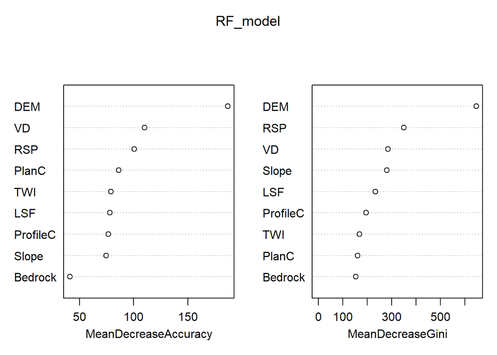

```r
sampleNum_dict[mn]<-nrow(sampData)

sampData$Bedrock<- droplevels(as.factor(sampData$Bedrock))
sampData$soilID<- droplevels(as.factor(sampData$soilID))

RF_model<-randomForest(soilID ~.,data = sampData,
                       importance = TRUE, proximity = FALSE,
                       ntree=1000,type="classification")

varImpPlot(RF_model)
```

```r
print(RF_model)
```

```
##
## Call:
##  randomForest(formula = soilID ~ ., data = sampData, importance = TRUE,      proximity = FALSE, ntree = 1000, type = "classification")
##                Type of random forest: classification
##                      Number of trees: 1000
## No. of variables tried at each split: 3
##
##         OOB estimate of  error rate: 19.27%
## Confusion matrix:
##      1  20 21  23   3 30  31 501 502 503   7 class.error
## 1   16   0  0   0   1  0   0   0   0   0   0  0.05882353
## 20   0 334 22   1   0  1   0   5   2  59  23  0.25279642
## 21   0  52 93   0   0  0   0   0   2  12   2  0.42236025
## 23   0   0  0 221   0 14   8   0   0  32   7  0.21631206
## 3    2   0  0   0 120  0   0  33   0   0   0  0.22580645
## 30   0   0  0  18   0 62   5   0   0   0   6  0.31868132
## 31   0   0  0  13   0  5 105   0   0   0   0  0.14634146
## 501  0   4  0   0  30  0   0 429   2   0   9  0.09493671
## 502  0   6  2   0   0  0   0   2  44   0   6  0.26666667
## 503  0  46  3  26   0  1   1   0   1 574  16  0.14071856
## 7    0  28  0   2   0  3   0  19   6  18 332  0.18627451
```

```r
map_RF <- predict(covStack, RF_model, paste(result_tif_folder,mn,".tif",sep=""),
                  format = "GTiff", datatype = "FLT4S", overwrite = TRUE)

rm("mn","shpPoint","sampData","RF_model","map_RF")
```

SNA Slope ns3 60

```r
mn="All_pSNA_Slope_NS3_pen60"

shpPoint<-readOGR(paste(point_shp_folder,mn,".shp",sep = "")) ###
sampData <- extract(covStack, shpPoint, sp = TRUE,method = "simple")

sampData<-sampData@data

sampData<-sampData[sampData$soilID %in% soil_type,]

sampData<-na.omit(sampData)

print(dim(sampData))
```

```
## [1] 3842   10
```

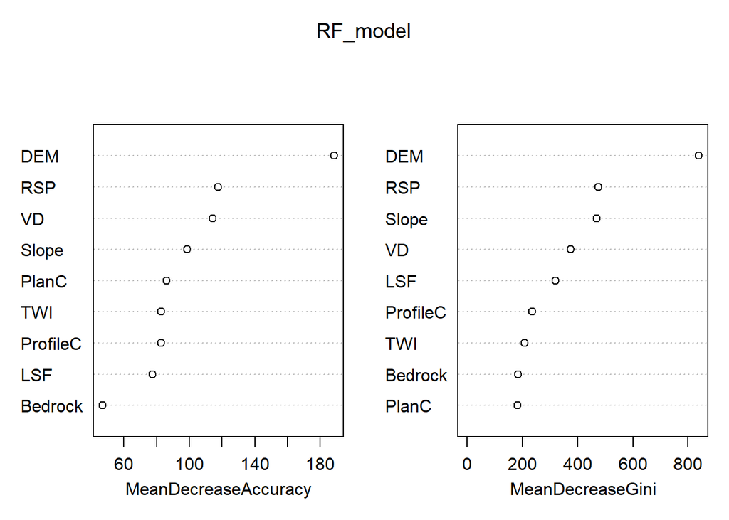

```r
sampleNum_dict[mn]<-nrow(sampData)

sampData$Bedrock<- droplevels(as.factor(sampData$Bedrock))
sampData$soilID<- droplevels(as.factor(sampData$soilID))

RF_model<-randomForest(soilID ~.,data = sampData,
                       importance = TRUE, proximity = FALSE,
                       ntree=1000,type="classification")

varImpPlot(RF_model)
```

```r
print(RF_model)
```

```
##
## Call:
##  randomForest(formula = soilID ~ ., data = sampData, importance = TRUE,      proximity = FALSE, ntree = 1000, type = "classification")
##                Type of random forest: classification
##                      Number of trees: 1000
## No. of variables tried at each split: 3
##
##         OOB estimate of  error rate: 18.3%
## Confusion matrix:
##      1  20  21  23   3 30  31 501 502 503   7 class.error
## 1   16   0   0   0   6  0   0   0   0   0   0  0.27272727
## 20   0 402  38   1   0  0   0   7   2  84  59  0.32209106
## 21   0  75 125   0   0  0   0   1   3  11   0  0.41860465
## 23   0   0   0 300   0 15   8   0   0  41  10  0.19786096
## 3    2   0   0   0 178  0   0  26   0   0   0  0.13592233
## 30   0   1   0  13   0 96   8   0   0   0   5  0.21951220
## 31   0   0   0   9   0  5 150   0   0   0   0  0.08536585
## 501  0   2   0   0  20  0   0 592   0   0  18  0.06329114
## 502  0   7   1   0   0  0   0   1  60   1   9  0.24050633
## 503  0  71   3  26   0  1   0   0   2 771  17  0.13468013
## 7    0  39   0   1   0  2   0  27   3  22 449  0.17311234
```

```r
map_RF <- predict(covStack, RF_model, paste(result_tif_folder,mn,".tif",sep=""),
                  format = "GTiff", datatype = "FLT4S", overwrite = TRUE)

rm("mn","shpPoint","sampData","RF_model","map_RF")
```

RAN Slope ns3 60

```r
mn="All_pRAN_Slope_NS3_pen60"

shpPoint<-readOGR(paste(point_shp_folder,mn,".shp",sep = "")) ###
sampData <- extract(covStack, shpPoint, sp = TRUE,method = "simple")

sampData<-sampData@data

sampData<-sampData[sampData$soilID %in% soil_type,]

sampData<-na.omit(sampData)

print(dim(sampData))
```

```
## [1] 3842   10
```

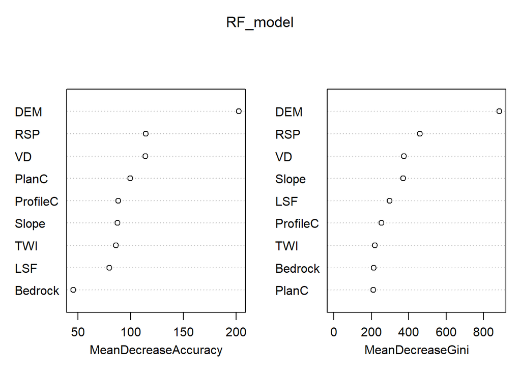

```r
sampleNum_dict[mn]<-nrow(sampData)

sampData$Bedrock<- droplevels(as.factor(sampData$Bedrock))
sampData$soilID<- droplevels(as.factor(sampData$soilID))

RF_model<-randomForest(soilID ~.,data = sampData,
                       importance = TRUE, proximity = FALSE,
                       ntree=1000,type="classification")

varImpPlot(RF_model)
```

```r
print(RF_model)
```

```
##
## Call:
##  randomForest(formula = soilID ~ ., data = sampData, importance = TRUE,      proximity = FALSE, ntree = 1000, type = "classification")
##                Type of random forest: classification
##                      Number of trees: 1000
## No. of variables tried at each split: 3
##
##         OOB estimate of  error rate: 18.56%
## Confusion matrix:
##      1  20  21  23   3 30  31 501 502 503   7 class.error
## 1   17   0   0   0   5  0   0   0   0   0   0  0.22727273
## 20   0 435  39   2   0  0   0   6   3  76  32  0.26644182
## 21   0  79 121   0   0  0   0   1   2  11   1  0.43720930
## 23   0   0   0 297   0 16  10   0   0  39  12  0.20588235
## 3    1   0   0   0 170  0   0  35   0   0   0  0.17475728
## 30   0   0   0  22   0 90   6   0   0   2   3  0.26829268
## 31   0   0   0  16   0  3 144   0   0   1   0  0.12195122
## 501  0  10   0   0  29  0   0 580   0   0  13  0.08227848
## 502  0   4   2   0   0  0   0   1  66   0   6  0.16455696
## 503  0  53   9  38   0  3   0   0   2 762  24  0.14478114
## 7    0  34   0   5   0  1   0  24   3  29 447  0.17679558
```

```r
map_RF <- predict(covStack, RF_model, paste(result_tif_folder,mn,".tif",sep=""),
                  format = "GTiff", datatype = "FLT4S", overwrite = TRUE)

rm("mn","shpPoint","sampData","RF_model","map_RF")
```

SNA Slope ns3 75

```r
mn="All_pSNA_Slope_NS3_pen75"

shpPoint<-readOGR(paste(point_shp_folder,mn,".shp",sep = "")) ###
sampData <- extract(covStack, shpPoint, sp = TRUE,method = "simple")

sampData<-sampData@data

sampData<-sampData[sampData$soilID %in% soil_type,]

sampData<-na.omit(sampData)

print(dim(sampData))
```

```
## [1] 4793   10
```

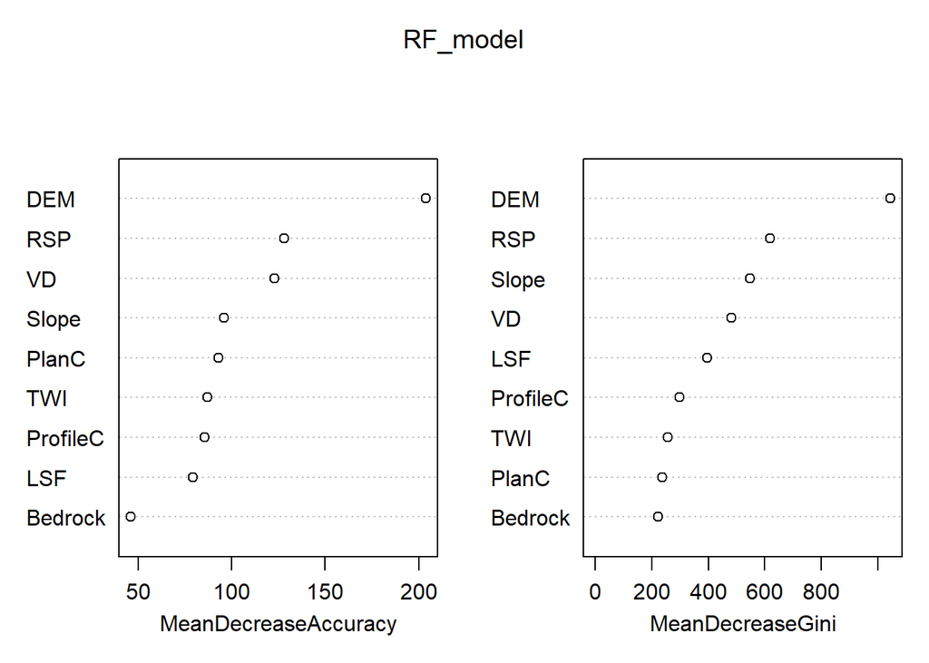

```r
sampleNum_dict[mn]<-nrow(sampData)

sampData$Bedrock<- droplevels(as.factor(sampData$Bedrock))
sampData$soilID<- droplevels(as.factor(sampData$soilID))

RF_model<-randomForest(soilID ~.,data = sampData,
                       importance = TRUE, proximity = FALSE,
                       ntree=1000,type="classification")

varImpPlot(RF_model)
```

```r
print(RF_model)
```

```
##
## Call:
##  randomForest(formula = soilID ~ ., data = sampData, importance = TRUE,      proximity = FALSE, ntree = 1000, type = "classification")
##                Type of random forest: classification
##                      Number of trees: 1000
## No. of variables tried at each split: 3
##
##         OOB estimate of  error rate: 18.42%
## Confusion matrix:
##      1  20  21  23   3  30  31 501 502 503   7 class.error
## 1   22   0   0   0   6   0   0   0   0   0   0  0.21428571
## 20   0 508  53   3   0   0   0   7   3  98  70  0.31536388
## 21   0  86 159   0   0   0   0   2   5  14   1  0.40449438
## 23   0   1   0 375   0  22   9   0   0  47  13  0.19700214
## 3    4   0   0   0 220   0   0  34   0   0   0  0.14728682
## 30   0   1   0  21   0 118   6   0   0   1   5  0.22368421
## 31   0   0   0  11   0   6 188   0   0   0   0  0.08292683
## 501  0   5   0   0  30   0   0 735   1   0  19  0.06962025
## 502  0   3   3   0   0   0   0   2  81   2   7  0.17346939
## 503  0  94   4  28   0   3   0   0   2 954  24  0.13976555
## 7    0  52   0   2   0   2   0  36   3  32 550  0.18759232
```

```r
map_RF <- predict(covStack, RF_model, paste(result_tif_folder,mn,".tif",sep=""),
                  format = "GTiff", datatype = "FLT4S", overwrite = TRUE)

rm("mn","shpPoint","sampData","RF_model","map_RF")
```

RAN Slope ns3 75

```r
mn="All_pRAN_Slope_NS3_pen75"

shpPoint<-readOGR(paste(point_shp_folder,mn,".shp",sep = "")) ###
sampData <- extract(covStack, shpPoint, sp = TRUE,method = "simple")

sampData<-sampData@data

sampData<-sampData[sampData$soilID %in% soil_type,]

sampData<-na.omit(sampData)

print(dim(sampData))
```

```
## [1] 4793   10
```

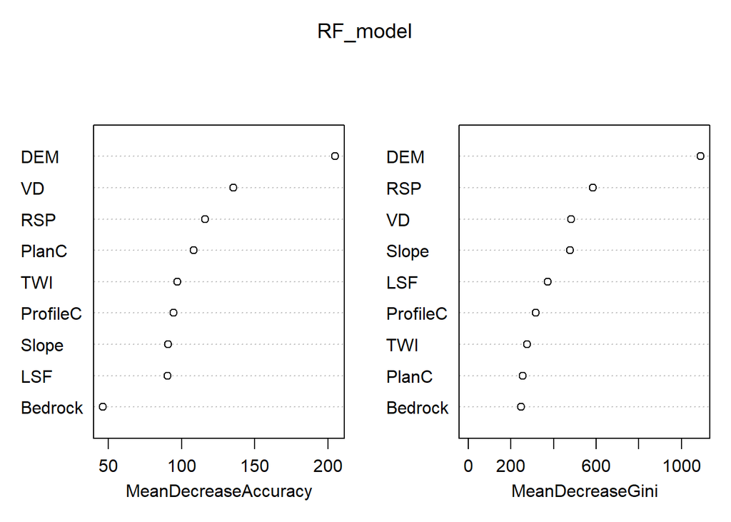

```r
sampleNum_dict[mn]<-nrow(sampData)

sampData$Bedrock<- droplevels(as.factor(sampData$Bedrock))
sampData$soilID<- droplevels(as.factor(sampData$soilID))

RF_model<-randomForest(soilID ~.,data = sampData,
                       importance = TRUE, proximity = FALSE,
                       ntree=1000,type="classification")

varImpPlot(RF_model)
```

```r
print(RF_model)
```

```
##
## Call:
##  randomForest(formula = soilID ~ ., data = sampData, importance = TRUE,      proximity = FALSE, ntree = 1000, type = "classification")
##                Type of random forest: classification
##                      Number of trees: 1000
## No. of variables tried at each split: 3
##
##         OOB estimate of  error rate: 16.44%
## Confusion matrix:
##      1  20  21  23   3  30  31 501 502 503   7 class.error
## 1   24   0   0   0   4   0   0   0   0   0   0  0.14285714
## 20   0 567  39   1   0   0   0   7   5  82  41  0.23584906
## 21   0  81 170   0   0   0   0   0   1  13   2  0.36329588
## 23   0   1   0 378   0  21   8   0   0  47  12  0.19057816
## 3    2   0   0   0 213   0   0  43   0   0   0  0.17441860
## 30   0   0   0  25   0 111   7   0   0   3   6  0.26973684
## 31   0   0   0  13   0   7 183   0   0   2   0  0.10731707
## 501  0   7   0   0  37   0   0 731   1   0  14  0.07468354
## 502  0   3   0   0   0   0   0   2  83   2   8  0.15306122
## 503  0  66   5  32   0   2   0   0   2 978  24  0.11812444
## 7    0  40   0   4   0   2   0  30   5  29 567  0.16248154
```

```r
map_RF <- predict(covStack, RF_model, paste(result_tif_folder,mn,".tif",sep=""),
                  format = "GTiff", datatype = "FLT4S", overwrite = TRUE)

rm("mn","shpPoint","sampData","RF_model","map_RF")
```

SNA Slope ns5 15

```r
mn="All_pSNA_Slope_NS5_pen15"

shpPoint<-readOGR(paste(point_shp_folder,mn,".shp",sep = "")) ###
sampData <- extract(covStack, shpPoint, sp = TRUE,method = "simple")

sampData<-sampData@data

sampData<-sampData[sampData$soilID %in% soil_type,]

sampData<-na.omit(sampData)

print(dim(sampData))
```

```
## [1] 336  10
```

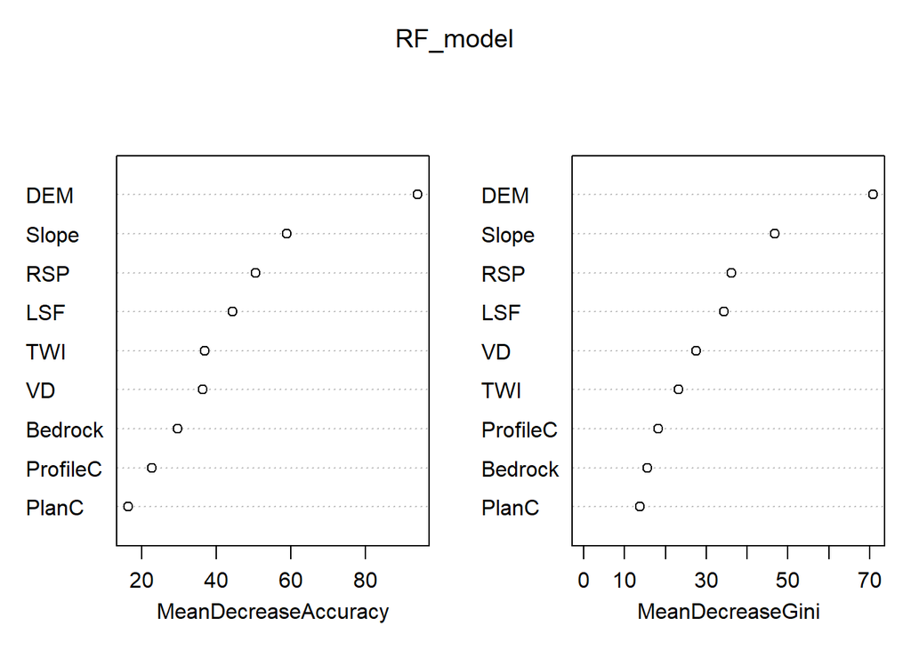

```r
sampleNum_dict[mn]<-nrow(sampData)

sampData$Bedrock<- droplevels(as.factor(sampData$Bedrock))
sampData$soilID<- droplevels(as.factor(sampData$soilID))

RF_model<-randomForest(soilID ~.,data = sampData,
                       importance = TRUE, proximity = FALSE,
                       ntree=1000,type="classification")

varImpPlot(RF_model)
```

```r
print(RF_model)
```

```
##
## Call:
##  randomForest(formula = soilID ~ ., data = sampData, importance = TRUE,      proximity = FALSE, ntree = 1000, type = "classification")
##                Type of random forest: classification
##                      Number of trees: 1000
## No. of variables tried at each split: 3
##
##         OOB estimate of  error rate: 25.3%
## Confusion matrix:
##     1 20 21 23  3 30 31 501 502 503  7 class.error
## 1   0  0  0  0  2  0  0   0   0   0  0  1.00000000
## 20  0 28  4  0  0  0  0   1   0   6  7  0.39130435
## 21  0  7 12  0  0  0  0   1   0   1  0  0.42857143
## 23  0  0  0 18  0  3  0   0   0   6  2  0.37931034
## 3   0  0  0  0 16  0  0   3   0   0  0  0.15789474
## 30  0  0  0  3  0  5  1   0   0   0  0  0.44444444
## 31  0  0  0  1  0  0 12   0   0   0  0  0.07692308
## 501 0  1  0  0  4  0  0  53   0   0  3  0.13114754
## 502 0  3  0  0  0  0  0   0   3   1  0  0.57142857
## 503 0  5  0  2  0  0  0   0   0  67  4  0.14102564
## 7   0  5  0  0  0  1  0   3   0   5 37  0.27450980
```

```r
map_RF <- predict(covStack, RF_model, paste(result_tif_folder,mn,".tif",sep=""),
                  format = "GTiff", datatype = "FLT4S", overwrite = TRUE)

rm("mn","shpPoint","sampData","RF_model","map_RF")
```

RAN Slope ns5 15

```r
mn="All_pRAN_Slope_NS5_pen15"

shpPoint<-readOGR(paste(point_shp_folder,mn,".shp",sep = "")) ###
sampData <- extract(covStack, shpPoint, sp = TRUE,method = "simple")

sampData<-sampData@data

sampData<-sampData[sampData$soilID %in% soil_type,]

sampData<-na.omit(sampData)

print(dim(sampData))
```

```
## [1] 336  10
```

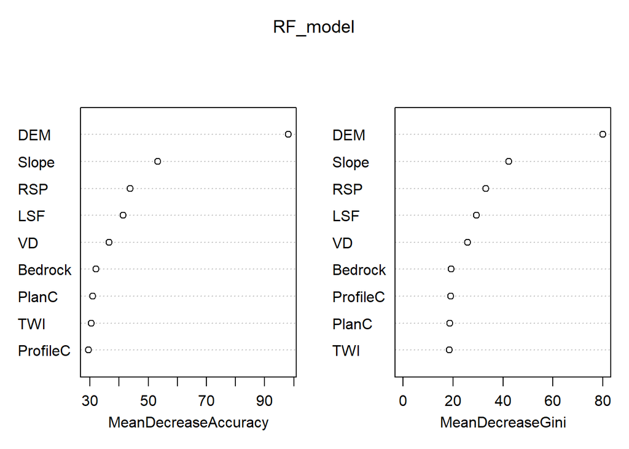

```r
sampleNum_dict[mn]<-nrow(sampData)

sampData$Bedrock<- droplevels(as.factor(sampData$Bedrock))
sampData$soilID<- droplevels(as.factor(sampData$soilID))

RF_model<-randomForest(soilID ~.,data = sampData,
                       importance = TRUE, proximity = FALSE,
                       ntree=1000,type="classification")

varImpPlot(RF_model)
```

```r
print(RF_model)
```

```
##
## Call:
##  randomForest(formula = soilID ~ ., data = sampData, importance = TRUE,      proximity = FALSE, ntree = 1000, type = "classification")
##                Type of random forest: classification
##                      Number of trees: 1000
## No. of variables tried at each split: 3
##
##         OOB estimate of  error rate: 23.21%
## Confusion matrix:
##     1 20 21 23  3 30 31 501 502 503  7 class.error
## 1   1  0  0  0  1  0  0   0   0   0  0  0.50000000
## 20  0 27  6  0  0  0  0   1   0   7  5  0.41304348
## 21  0  8 12  0  0  0  0   0   0   1  0  0.42857143
## 23  0  0  0 22  0  3  0   0   0   3  1  0.24137931
## 3   0  0  0  0 15  0  0   4   0   0  0  0.21052632
## 30  0  0  0  2  0  2  2   0   0   0  3  0.77777778
## 31  0  0  0  1  0  0 12   0   0   0  0  0.07692308
## 501 0  0  0  0  2  0  0  58   1   0  0  0.04918033
## 502 0  3  0  0  0  0  0   3   0   0  1  1.00000000
## 503 0  2  0  2  0  0  0   0   0  71  3  0.08974359
## 7   0  5  0  0  0  3  0   2   0   3 38  0.25490196
```